# The Athlete Microbiome Project: Identifying Underlying Microbial Associations with Athletic Performance

Garry Lewis, Sebastian Reczek, Jarrad Hampton-Marcell

2024-10-23

# Prepare the data

```r
# Libraries
library(phyloseq)                           # For microbiome data handling

# Load Data
setwd("/scratch/marcellab/athlete_study/tables")
file <- import_biom("all_studies_merged_json.biom")

setwd("/scratch/marcellab/athlete_study")
map <- import_qiime_sample_data("all_studies_mapping.txt") # Metadata

# Replace missing taxonomy entries with "Unclassified"
tax_table(file) <- apply(tax_table(file), 2, function(x) ifelse(is.na(x) | x == "", "Unclassified", x))

# Merge Data Together
athlete <- merge_phyloseq(file,map)

# Remove Single OTUs
ath_no_single = prune_taxa(taxa_sums(athlete) > 1, athlete)

# Rename Taxonomic Levels from Rank to Actual Name
colnames(tax_table(ath_no_single)) <- c("Domain",
                                        "Phylum",
                                        "Class",
                                        "Order",
                                        "Family",
                                        "Genus",
                                        "Species")

# Remove Outlier Sample
ath_no_single <- subset_samples(ath_no_single, Target == "Yes")

# Remove NAs
ath_no_single <- subset_samples(ath_no_single, Gender != "NA")

ath <- ath_no_single

# Create Distance Matrix & Data Frame
df_ath <- as(sample_data(ath), "data.frame")


# Change Levels

sample_data(ath)$Person_Type <- factor(sample_data(ath)$Person_Type,
                                       levels = c("Athlete",
                                                  "Gen.Pop"),
                                       labels = c("Athlete",
                                                  "Non-Athlete"), ordered=TRUE)

df_ath$Person_Type <- factor(df_ath$Person_Type,
                             levels = c("Athlete",
                                        "Gen.Pop"),
                             labels = c("Athlete",
                                        "Non-Athlete"))

#######################################################
########## Tidy up sample ID data (subject ID's)########
########################################################

# Rename variable
ath2 <- ath
sample_data(ath2)$Sample <- sample_data(ath2)$SampleID

# Convert samples to a factor
sample_factor <- factor(sample_data(ath2)$Sample)

# Add numerical column representing the samples
sample_column <- as.numeric(sample_factor)

sample_data(ath2)$Sample <- sample_column

# Aggregating data at the genus level
ath2 <- tax_glom(ath2, "Genus")

# Clean taxonomy again AFTER aggregation
tax_table(ath2) <- apply(tax_table(ath2), 2, function(x) ifelse(is.na(x) | x == "", "Unclassified", x))

#######################################################################################################################
##Apply a function that removes assigns NA to any missing "" in taxa table, removes [] content, and removes g__, ect. #
########################################################################################################################
clean_taxa <- function(name) {
  # Remove prefixes like g__, o__, etc.
  name <- gsub("^[a-z]__", "", name)

  # Remove bracketed content
  name <- gsub("\\[.*\\]", "", name)

  # Remove leading and trailing white spaces
  name <- trimws(name)

  # Replace empty strings with NA
  if (nzchar(name)) {
    return(name)
  } else {
    return(NA)
  }
}

tax_table(ath2) <- apply(tax_table(ath2), 2, function(x) sapply(x, clean_taxa))
```

## Normilization

#### Convert the raw counts into relative abundances, sacling each sample to a sum of 1. This ensures that samples are comparabile in terms of portions. First determine the best pseudo count by taking min value that isn’t zero and dividing by 2. Adding a psuedo count avoids the log of zero 0 during CLR transformation. CLR applies a log transformation to the data, making it more suitable for compostional data like relative abundances.

```r
# Normalize to relative abundance
ath2_rel_abundance <- transform_sample_counts(ath2, function(x) x / sum(x))

# Extract the OTU table
otu_data <- otu_table(ath2_rel_abundance)

# Convert to matrix for manipulation
otu_matrix <- as.matrix(otu_data)

# Flatten the matrix to a single vector to avoid dimension-related subscript issues
otu_vector <- c(otu_matrix)

# Find the minimum non-zero value in the vector
min_nonzero_value <- min(otu_vector[otu_vector > 0])

# Divide the min value by 2.
min_nonzero_value_div <- min_nonzero_value/2

pseudo_count <- min_nonzero_value_div  # Adjust based on your data
ath2_rel_abundance_pseudo <- transform_sample_counts(ath2_rel_abundance, function(x) x + pseudo_count)

# Manual CLR transformation remains the same
clr_transformation <- function(x) {
  log_x <- log(x)
  geometric_mean <- exp(mean(log_x, na.rm = TRUE))
  clr_x <- log_x - log(geometric_mean)
  return(clr_x)
}
```

# Measures of Physical Fitness Correlate with Microbial Composition

## Comparing the measurements of each feature between Athlete and non-athlete (Age, Weight, VO2max, BC, ect)

#### Convert the sample_data of the phyloseq file into a data frame. Then perform an ANOVA test to compare the means between the Athletes and Non-Athletes on their weight, height, and age to determine if there is any signifcant difference between the two groups. Finally, generate a table that measures the means and standard deviations of the two groups on the measured characteristics.

```r
# Convert the sample data in the phyloseq object to a data frame
sample_metadata_df <- data.frame(sample_data(ath2))

# Check if the data frame has been created successfully
str(sample_metadata_df)
```

```
## 'data.frame':    855 obs. of  21 variables:
##  $ SampleID        : chr  "219-315-514" "311-949-230" "331-949-185" "436-325-187" ...
##  $ Target          : chr  "Yes" "Yes" "Yes" "Yes" ...
##  $ Study           : chr  "Cook" "Cook" "Cook" "Cook" ...
##  $ Person_Type     : Ord.factor w/ 2 levels "Athlete"<"Non-Athlete": 1 1 1 1 1 1 1 1 1 1 ...
##  $ Sport           : chr  "Track" "Football" "Track" "Basketball" ...
##  $ Continent       : chr  "America" "America" "America" "America" ...
##  $ Country         : chr  "USA" "USA" "USA" "USA" ...
##  $ Region          : chr  "North Carolina" "North Carolina" "North Carolina" "North Carolina" ...
##  $ Person_ID       : chr  "Cook.13" "Cook.18" "Cook.14" "Cook.27" ...
##  $ Exercise_Type   : chr  "Aerobic" "Anaerobic" "Aerobic" "Anaerobic" ...
##  $ Height_cm       : num  156 179 165 196 182 ...
##  $ Weight_kg       : num  54.9 123 60.6 83.4 67.4 ...
##  $ Age             : int  22 21 20 18 20 18 20 18 21 19 ...
##  $ BMI             : num  22.5 38.4 22.2 21.8 20.4 ...
##  $ RMR             : num  1256 2250 1378 1972 1715 ...
##  $ Fat_Percent     : num  19.3 38.9 21.2 7.9 8.5 13.9 15.3 11.1 17.6 9.4 ...
##  $ Fat_Free_Percent: num  49.3 86.2 50.7 85.4 68.3 59.1 75.3 65.6 52.6 62.9 ...
##  $ VO2max          : num  49.5 40.2 44.4 65.7 81.7 65.1 52.2 54.5 50.7 64.5 ...
##  $ Gender          : chr  "Female" "Male" "Female" "Male" ...
##  $ Description     : chr  "219-315-514" "311-949-230" "331-949-185" "436-325-187" ...
##  $ Sample          : num  71 72 73 74 75 76 77 78 79 80 ...
```

```r
# Libraries for ANOVA and data manipulation
library(dplyr)                # For data manipulation
# Perform ANOVA tests on Weight, Height, and Age between athletes and non-athletes
anova_weight <- aov(Weight_kg ~ Person_Type, data = sample_metadata_df)
anova_height <- aov(Height_cm ~ Person_Type, data = sample_metadata_df)
anova_age <- aov(Age ~ Person_Type, data = sample_metadata_df)

# Extract p-values (ensure you're pulling from the correct place in the ANOVA summary)
p_value_weight <- summary(anova_weight)[[1]][["Pr(>F)"]][1]
p_value_height <- summary(anova_height)[[1]][["Pr(>F)"]][1]
p_value_age <- summary(anova_age)[[1]][["Pr(>F)"]][1]

# Determine significance (p < 0.05 is significant)
significance_weight <- ifelse(p_value_weight < 0.05, "Significant", "Not Significant")
significance_height <- ifelse(p_value_height < 0.05, "Significant", "Not Significant")
significance_age <- ifelse(p_value_age < 0.05, "Significant", "Not Significant")

# Create a summary table for ANOVA results
anova_results_table <- data.frame(
  Measure = c("Weight", "Height", "Age"),
  P_Value = c(p_value_weight, p_value_height, p_value_age),
  Significance = c(significance_weight, significance_height, significance_age)
)

# Display ANOVA results
print(anova_results_table)
```

```
##   Measure      P_Value    Significance
## 1  Weight 5.289083e-01 Not Significant
## 2  Height 1.665139e-01 Not Significant
## 3     Age 6.023430e-57     Significant
```

### Table 2

```r
# Sample characteristics table
sample_characteristics_table <- sample_metadata_df %>%
  group_by(Person_Type) %>%
  summarise(
    Weight_Mean = mean(Weight_kg, na.rm = TRUE),
    Weight_SD = sd(Weight_kg, na.rm = TRUE),
    Height_Mean = mean(Height_cm, na.rm = TRUE),
    Height_SD = sd(Height_cm, na.rm = TRUE),
    Age_Mean = mean(Age, na.rm = TRUE),
    Age_SD = sd(Age, na.rm = TRUE),
    BMI_Mean = mean(BMI, na.rm = TRUE),
    BMI_SD = sd(BMI, na.rm = TRUE),
    RMR_Mean = mean(RMR, na.rm = TRUE),
    RMR_SD = sd(RMR, na.rm = TRUE),
    VO2max_Mean = mean(VO2max, na.rm = TRUE),
    VO2max_SD = sd(VO2max, na.rm = TRUE)
  )

# Display sample characteristics
print(sample_characteristics_table)
```

```
## # A tibble: 2 × 13
##   Person_Type Weight_Mean Weight_SD Height_Mean Height_SD Age_Mean Age_SD
##   <ord>             <dbl>     <dbl>       <dbl>     <dbl>    <dbl>  <dbl>
## 1 Athlete            63.9      12.8        168.      8.80     19.7   2.69
## 2 Non-Athlete        63.1      15.4        170.     10.8      26.4   7.66
## # ℹ 6 more variables: BMI_Mean <dbl>, BMI_SD <dbl>, RMR_Mean <dbl>,
## #   RMR_SD <dbl>, VO2max_Mean <dbl>, VO2max_SD <dbl>
```

```r
# Format and display the table using knitr
library(knitr)  #for integrating R code in Markdown documents

kable(sample_characteristics_table, caption = "SAMPLE CHARACTERISTICS")
```

SAMPLE CHARACTERISTICS

| Person_Type | Weight_Mean | Weight_SD | Height_Mean | Height_SD | Age_Mean | Age_SD | BMI_Mean | BMI_SD | RMR_Mean | RMR_SD | VO2max_Mean | VO2max_SD |
| --- | --- | --- | --- | --- | --- | --- | --- | --- | --- | --- | --- | --- |
| Athlete | 63.87471 | 12.81437 | 168.4796 | 8.800643 | 19.68284 | 2.691602 | 22.31704 | 2.816986 | 1523.258 | 218.9461 | 47.12514 | 11.690889 |
| Non-Athlete | 63.10784 | 15.38960 | 169.6444 | 10.829042 | 26.40132 | 7.663675 | 21.69545 | 3.693157 | 1477.920 | 278.3870 | 40.42958 | 9.669319 |

### Determine the overall counts of the filtered data.

```r
# Number of samples (n)
n_samples <- nsamples(ath2)

# Total number of sequences (sum of all OTU counts across all samples)
total_sequences <- sum(sample_sums(ath2))

# Number of OTUs (number of unique taxa/OTUs)
n_otus <- ntaxa(ath2)

# Display the results
cat("Number of samples (n):", n_samples, "\n")
```

```
## Number of samples (n): 855
```

```r
cat("Total number of sequences:", total_sequences, "\n")
```

```
## Total number of sequences: 60383004
```

```r
cat("Number of OTUs:", n_otus, "\n")
```

```
## Number of OTUs: 735
```

## RF for GM predicting Fat free mass (body comp) - Figure 1A-B

#### Prepare the phyloseq for analysis using a Regression Random Forest by first removing all NAs. To calculate the Mean Squared error (MSE), the range was calculated. The training set was prepared, predictor variable was the OTUs from the Gut microbiome and the response variable was the Fat Free Percent (body composition). Using the MSE the importance scores were extracted from the model. The top ten taxa are filtered out and observed against Fat Free Percent using spearman rank correlations.

```r
# Libraries
library(phyloseq)      # For microbiome data handling
library(randomForest)  # For random forest modeling
```

```r
library(ggplot2)       # For plotting
library(dplyr)         # For data manipulation
library(ggpubr)        # For adding statistical annotations to ggplots

#Remove all NAs
# Assuming 'ath2' is your phyloseq object and you want to remove samples where Fat_Free_Percent is not between 0 and 100
ath2_BC <- subset_samples(ath2, !is.na(Fat_Free_Percent) & Fat_Free_Percent >= 0 & Fat_Free_Percent <= 100)

# Replace NA values with "Unclassified" in the taxonomic table
tax_table(ath2_BC) <- apply(tax_table(ath2_BC), 2, function(x) ifelse(is.na(x) | x == "", "Unclassified", x))

# Remove unclassified taxa before running RF
ath2_BC <- subset_taxa(ath2_BC, Genus != "Unclassified")

# Check the first few rows of the sample data to ensure NA values in VO2max are removed
head(sample_data(ath2_BC))
```

```
##                SampleID Target Study Person_Type      Sport Continent Country
## 219-315-514 219-315-514    Yes  Cook     Athlete      Track   America     USA
## 311-949-230 311-949-230    Yes  Cook     Athlete   Football   America     USA
## 331-949-185 331-949-185    Yes  Cook     Athlete      Track   America     USA
## 436-325-187 436-325-187    Yes  Cook     Athlete Basketball   America     USA
## 437-325-082 437-325-082    Yes  Cook     Athlete Basketball   America     USA
## 438-326-095 438-326-095    Yes  Cook     Athlete Basketball   America     USA
##                     Region Person_ID Exercise_Type Height_cm Weight_kg Age
## 219-315-514 North Carolina   Cook.13       Aerobic   156.210  54.92063  22
## 311-949-230 North Carolina   Cook.18     Anaerobic   179.070 122.99320  21
## 331-949-185 North Carolina   Cook.14       Aerobic   165.100  60.58957  20
## 436-325-187 North Carolina   Cook.27     Anaerobic   195.580  83.40136  18
## 437-325-082 North Carolina   Cook.28     Anaerobic   181.610  67.43764  20
## 438-326-095 North Carolina   Cook.21     Anaerobic   173.228  62.90249  18
##                  BMI      RMR Fat_Percent Fat_Free_Percent VO2max Gender
## 219-315-514 22.50701 1255.730        19.3             49.3   49.5 Female
## 311-949-230 38.35619 2249.570        38.9             86.2   40.2   Male
## 331-949-185 22.22817 1377.765        21.2             50.7   44.4 Female
## 436-325-187 21.80340 1971.995         7.9             85.4   65.7   Male
## 437-325-082 20.44668 1715.365         8.5             68.3   81.7   Male
## 438-326-095 20.96195 1627.511        13.9             59.1   65.1   Male
##             Description Sample
## 219-315-514 219-315-514     71
## 311-949-230 311-949-230     72
## 331-949-185 331-949-185     73
## 436-325-187 436-325-187     74
## 437-325-082 437-325-082     75
## 438-326-095 438-326-095     76
```

```r
##Use this to determine if the MSR is a good fit of for the data.
# Calculate the minimum and maximum values of the Fat_Free_Percent variable
min_value <- min(sample_data(ath2_BC)$Fat_Free_Percent, na.rm = TRUE)
max_value <- max(sample_data(ath2_BC)$Fat_Free_Percent, na.rm = TRUE)

# Calculate the range by subtracting the minimum from the maximum
range_value <- max_value - min_value

# Print the results
cat("Minimum Fat-Free Percent:", min_value, "\n")
```

```
## Minimum Fat-Free Percent: 43.094
```

```r
cat("Maximum Fat-Free Percent:", max_value, "\n")
```

```
## Maximum Fat-Free Percent: 94.4
```

```r
cat("Range of Fat-Free Percent:", range_value, "\n")
```

```
## Range of Fat-Free Percent: 51.306
```

```r
# Make Training Dataset
predict3 <- t(otu_table(ath2_BC))


# Create response variable (AGE_CAT)
res3 <- sample_data(ath2_BC)$Fat_Free_Percent

# Combine them into 1 data frame
machine.data3 <- data.frame(res3, predict3)
dim(machine.data3)
```

```
## [1] 156 425
```

```r
# Check total number of samples (n)
total_ffm_samples <- nrow(sample_data(ath2_BC))  # assuming ath2_BC is your body comp dataset

# Check the number of athletes and non-athletes
athlete_count_ffm <- sum(sample_data(ath2_BC)$Person_Type == "Athlete")
non_athlete_count_ffm <- sum(sample_data(ath2_BC)$Person_Type == "Non-Athlete")

cat("Total samples (Body Comp model):", total_ffm_samples, "\n")
```

```
## Total samples (Body Comp model): 156
```

```r
cat("Athletes (Body Comp model):", athlete_count_ffm, "\n")
```

```
## Athletes (Body Comp model): 156
```

```r
cat("Non-Athletes (Body Comp model):", non_athlete_count_ffm, "\n")
```

```
## Non-Athletes (Body Comp model): 0
```

```r
set.seed(8)

class.BC <- randomForest(res3 ~ ., data=machine.data3, ntree = 1000, importance = TRUE)
print(class.BC)
```

```
##
## Call:
##  randomForest(formula = res3 ~ ., data = machine.data3, ntree = 1000,      importance = TRUE)
##                Type of random forest: regression
##                      Number of trees: 1000
## No. of variables tried at each split: 141
##
##           Mean of squared residuals: 50.81537
##                     % Var explained: 65.84
```

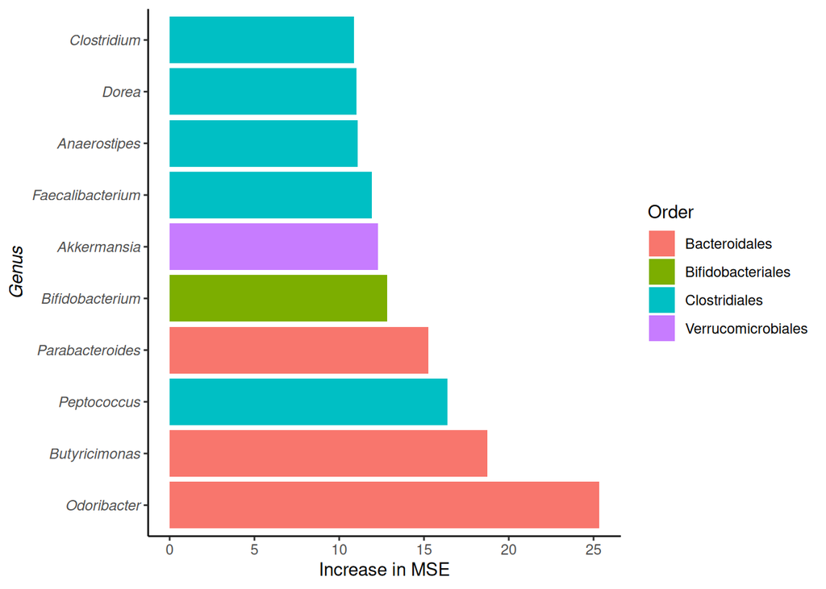

```r
# Extract importance scores
imp_BC <- randomForest::importance(class.BC)
imp_BC_df <- data.frame(OTUID = rownames(imp_BC), imp_BC)

# Remove 'X' prefix from 'OTUID'
imp_BC_df$OTUID <- gsub("X", "", imp_BC_df$OTUID)

otu_df_BC <- as.data.frame(tax_table(ath2_BC))
otu_df_BC$OTUID <- rownames(otu_df_BC)

# Assuming imp_BC_df contains importance scores and otu_df_BC contains taxonomic information
imp_BC_merged <- merge(imp_BC_df, otu_df_BC, by = "OTUID")

# Now, sort this aggregated data to identify the top taxa
imp_BC_merged <- arrange(imp_BC_merged, desc(X.IncMSE))

imp_BC_top10 <- head(imp_BC_merged, 10)

# Figure 1A - Generate a Mean Standard Error
Fig1A <- ggplot(imp_BC_top10, aes(x = reorder(Genus, X.IncMSE, decreasing = TRUE), y = X.IncMSE, fill = Order)) +
  geom_bar(stat = "identity") +
  coord_flip() +
  theme_classic() +
  labs(x = expression(italic("Genus")),
       y = "Increase in MSE",
       fill = "Order") +
  theme(axis.text.y = element_text(face = "italic"))

Fig1A
```

```r
# Filter ath.genera3 to include only the top 10 taxa identified in imp_BC_top10
top_genera3 <- unique(imp_BC_top10$Genus) # Assuming the top 10 are already selected

# Create a taxa dataframe
ath_genera_BC <- ath2_BC %>%
  #tax_glom(taxrank = "Genus") %>%  # Aggregate at Genus level
  psmelt() %>%                     # Melt to long format
  arrange(Order)                   # Optional: Order by taxonomic Orde
```

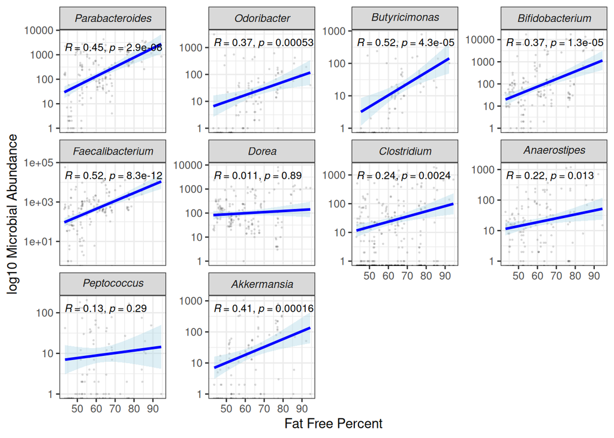

```r
ath.genera3_filtered <- ath_genera_BC %>%
  filter(Genus %in% top_genera3)

# Make genera italic
ath.genera3_filtered <- ath_genera_BC %>%
  filter(Genus %in% top_genera3) %>%
  mutate(Genus = factor(Genus, levels = unique(Genus), labels = paste0("italic('", unique(Genus), "')")))

# Plot spearmans
Fig1B <- ggplot(ath.genera3_filtered, aes(x = Fat_Free_Percent, y = Abundance)) +
  geom_point(color = "black", alpha = 0.1, size = 0.25) +
  scale_y_log10() +
  geom_smooth(method = "lm", se = TRUE, color = "blue", fill = "lightblue") +  # Add LM line of best fit
  stat_cor(method = "spearman", size = 3) +  # Reduce font size for R and p values
  facet_wrap(~Genus, scales = "free_y", labeller = label_parsed) +
  labs(y = "log10 Microbial Abundance", x = "Fat Free Percent") +
  theme_bw()

Fig1B
```

## RF for GM predicting VO2max - Figure 1C-D

#### Prepare the phyloseq for analysis using a Regression Random Forest by first removing all NAs. To calculate the Mean Squared error (MSE), the range was calculated. The training set was prepared, predictor variable was the OTUs from the Gut microbiome and the response variable was the VO2max. Using the MSE the importance scores were extracted from the model. The top ten taxa are filtered out and observed against VO2max scores using spearman rank correlations.

```r
# Libraries
library(phyloseq)      # For microbiome data handling
library(randomForest)  # For random forest modeling
library(ggplot2)       # For plotting
library(dplyr)         # For data manipulation
library(ggpubr)        # For adding statistical annotations to ggplots


#Remove all NAs
ath2_VO2max <- subset_samples(ath2, !is.na(VO2max))

# Remove unclassified taxa before running RF
ath2_VO2max <- subset_taxa(ath2_VO2max, Genus != "Unclassified")

# Check the first few rows of the sample data to ensure NA values in VO2max are removed
head(sample_data(ath2_VO2max))
```

```
##                SampleID Target Study Person_Type      Sport Continent Country
## 219-315-514 219-315-514    Yes  Cook     Athlete      Track   America     USA
## 311-949-230 311-949-230    Yes  Cook     Athlete   Football   America     USA
## 331-949-185 331-949-185    Yes  Cook     Athlete      Track   America     USA
## 436-325-187 436-325-187    Yes  Cook     Athlete Basketball   America     USA
## 437-325-082 437-325-082    Yes  Cook     Athlete Basketball   America     USA
## 438-326-095 438-326-095    Yes  Cook     Athlete Basketball   America     USA
##                     Region Person_ID Exercise_Type Height_cm Weight_kg Age
## 219-315-514 North Carolina   Cook.13       Aerobic   156.210  54.92063  22
## 311-949-230 North Carolina   Cook.18     Anaerobic   179.070 122.99320  21
## 331-949-185 North Carolina   Cook.14       Aerobic   165.100  60.58957  20
## 436-325-187 North Carolina   Cook.27     Anaerobic   195.580  83.40136  18
## 437-325-082 North Carolina   Cook.28     Anaerobic   181.610  67.43764  20
## 438-326-095 North Carolina   Cook.21     Anaerobic   173.228  62.90249  18
##                  BMI      RMR Fat_Percent Fat_Free_Percent VO2max Gender
## 219-315-514 22.50701 1255.730        19.3             49.3   49.5 Female
## 311-949-230 38.35619 2249.570        38.9             86.2   40.2   Male
## 331-949-185 22.22817 1377.765        21.2             50.7   44.4 Female
## 436-325-187 21.80340 1971.995         7.9             85.4   65.7   Male
## 437-325-082 20.44668 1715.365         8.5             68.3   81.7   Male
## 438-326-095 20.96195 1627.511        13.9             59.1   65.1   Male
##             Description Sample
## 219-315-514 219-315-514     71
## 311-949-230 311-949-230     72
## 331-949-185 331-949-185     73
## 436-325-187 436-325-187     74
## 437-325-082 437-325-082     75
## 438-326-095 438-326-095     76
```

```r
# Make Training Dataset
predict2 <- t(otu_table(ath2_VO2max))
dim(predict2)
```

```
## [1] 344 424
```

```r
# Create response variable (AGE_CAT)
res2 <- sample_data(ath2_VO2max)$VO2max

# Combine them into 1 data frame
machine.data2 <- data.frame(res2, predict2)
dim(machine.data2)
```

```
## [1] 344 425
```

```r
# Check total number of samples (n)
total_vo2_samples <- nrow(sample_data(ath2_VO2max))

# Check the number of athletes and non-athletes
athlete_count_vo2 <- sum(sample_data(ath2_VO2max)$Person_Type == "Athlete")
non_athlete_count_vo2 <- sum(sample_data(ath2_VO2max)$Person_Type == "Non-Athlete")

cat("Total samples (VO2max model):", total_vo2_samples, "\n")
```

```
## Total samples (VO2max model): 344
```

```r
cat("Athletes (VO2max model):", athlete_count_vo2, "\n")
```

```
## Athletes (VO2max model): 268
```

```r
cat("Non-Athletes (VO2max model):", non_athlete_count_vo2, "\n")
```

```
## Non-Athletes (VO2max model): 76
```

```r
##Use this to determine if the MSR is a good fit of for the data.
# Calculate the minimum and maximum values of the Fat_Free_Percent variable
min_value_V <- min(sample_data(ath2_VO2max)$VO2max, na.rm = TRUE)
max_value_V <- max(sample_data(ath2_VO2max)$VO2max, na.rm = TRUE)

# Calculate the range by subtracting the minimum from the maximum
range_value_V <- max_value_V - min_value_V

# Print the results
cat("Minimum VO2max:", min_value_V, "\n")
```

```
## Minimum VO2max: 18.97655
```

```r
cat("Maximum VO2maxt:", max_value_V, "\n")
```

```
## Maximum VO2maxt: 81.7
```

```r
cat("Range of VO2max:", range_value_V, "\n")
```

```
## Range of VO2max: 62.72345
```

```r
set.seed(8)

class.VO2max <- randomForest(res2 ~ ., data=machine.data2, ntree = 1000, importance = TRUE)
print(class.VO2max)
```

```
##
## Call:
##  randomForest(formula = res2 ~ ., data = machine.data2, ntree = 1000,      importance = TRUE)
##                Type of random forest: regression
##                      Number of trees: 1000
## No. of variables tried at each split: 141
##
##           Mean of squared residuals: 73.20026
##                     % Var explained: 45.45
```

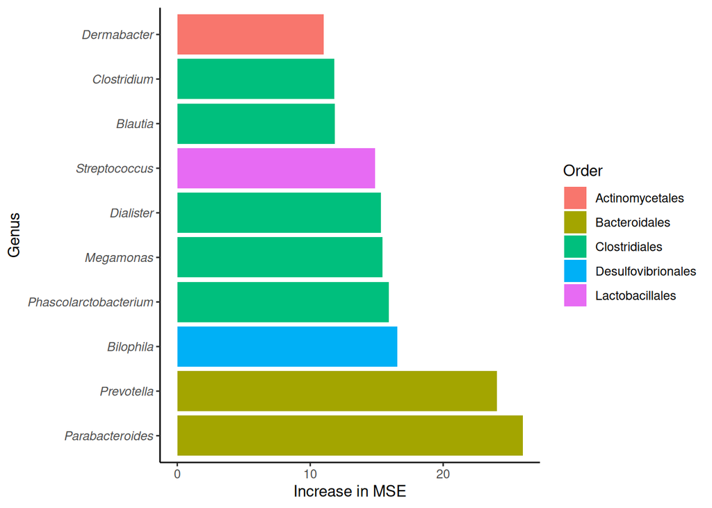

```r
# Extract importance scores
imp_VO2max <- randomForest::importance(class.VO2max)
imp_VO2max_df <- data.frame(OTUID = rownames(imp_VO2max), imp_VO2max)

# Remove 'X' prefix from 'OTUID'
imp_VO2max_df$OTUID <- gsub("X", "", imp_VO2max_df$OTUID)

# Prepare the OTU dataframe with taxonomic information
otu_df2 <- as.data.frame(tax_table(ath2_VO2max))
otu_df2$OTUID <- rownames(otu_df2)

# Merge importance scores with taxonomic information
imp_VO2max_merged <- merge(imp_VO2max_df, otu_df2, by = "OTUID")


# Now, sort this aggregated data to identify the top taxa
imp_VO2max_merged <- arrange(imp_VO2max_merged, desc(X.IncMSE))

imp_VO2max_top10 <- head(imp_VO2max_merged, 10)

# Replace NA values in the Genus column with "Unclassified" for the MSE figure data
imp_VO2max_top10$Genus[is.na(imp_VO2max_top10$Genus)] <- "Unclassified"

# ggplot to use aggregated data for Increase MSE
Fig1C <- ggplot(imp_VO2max_top10, aes(x = reorder(Genus, X.IncMSE, decreasing = TRUE), y = X.IncMSE, fill = Order)) +
  geom_bar(stat = "identity") +
  coord_flip() +
  theme_classic() +
  labs(x = "Genus",
       y = "Increase in MSE",
       fill = "Order")+
  theme(axis.text.y = element_text(face = "italic"))

Fig1C
```

```r
# Filter ath.genera2 to include only the top 10 taxa identified in imp_VO2max_aggregated_with_NA
top_genera2 <- unique(imp_VO2max_top10$Genus) # Assuming the top 10 are already selected

# Create a taxa dataframe
ath_genera_VO2max <- ath2_VO2max %>%
  #tax_glom(taxrank = "Genus") %>%  # Aggregate at Genus level
  psmelt() %>%                     # Melt to long format
  arrange(Order)                   # Optional: Order by taxonomic Order
```

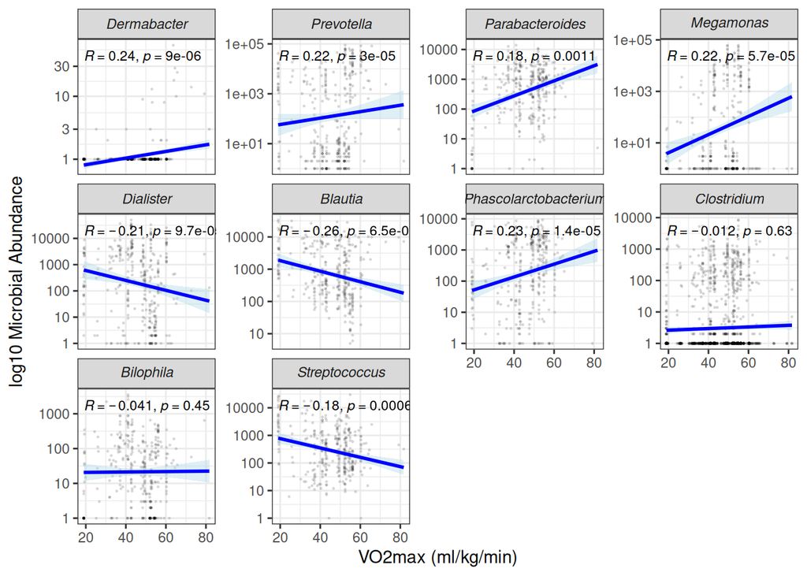

```r
# Create a filtered version of ath.genera that reflects what you aggregated.
ath.genera2_filtered <- ath_genera_VO2max %>%
  filter(Genus %in% top_genera2)

# Add a small constant to the abundance values to avoid issues with log10(0)
ath.genera2_filtered$Abundance <- ath.genera2_filtered$Abundance + 1

# Modify Genus column to be parsed for italics
ath.genera2_filtered <- ath_genera_VO2max %>%
  filter(Genus %in% top_genera2) %>%
  mutate(Genus = factor(Genus, levels = unique(Genus),
                        labels = paste0("italic('", unique(Genus), "')")))

# Add a small constant to the abundance values to avoid log10(0) issues
ath.genera2_filtered$Abundance <- ath.genera2_filtered$Abundance + 1

# Spearman correlation of VO2max and abundance of each Taxa
Fig1D <- ggplot(ath.genera2_filtered, aes(x = VO2max, y = Abundance)) +
  geom_point(color = "black", alpha = 0.1, size = 0.25) +
  scale_y_log10() +
  geom_smooth(method = "lm", se = TRUE, color = "blue", fill = "lightblue") +  # Add LM line of best fit
  stat_cor(method = "spearman", size = 3) +  # Reduce font size for R and p values
  facet_wrap(~Genus, scales = "free_y", labeller = label_parsed) +  # Ensure italics render correctly
  labs(y = "log10 Microbial Abundance", x = "VO2max (ml/kg/min)") +
  theme_bw()

Fig1D
```

# Combine figures 1A-D and format to dpi = 300

```r
# Load necessary libraries
library(ggpubr)
library(cowplot)
# Extract legends from Fig1A and Fig1C (keep Order classification)
legend_A <- get_legend(Fig1A)
legend_C <- get_legend(Fig1C)
# Remove legends from individual plots to avoid duplication
Fig1A_clean <- Fig1A + theme(legend.position = "none")
Fig1B_clean <- Fig1B + theme(legend.position = "none")
Fig1C_clean <- Fig1C + theme(legend.position = "none")
Fig1D_clean <- Fig1D + theme(legend.position = "none")

# Arrange A with its legend and C with its legend
Fig1A_with_legend <- ggarrange(Fig1A_clean, legend_A,
                               ncol = 2, widths = c(3, 0.7))  # Keep legend close

Fig1C_with_legend <- ggarrange(Fig1C_clean, legend_C,
                               ncol = 2, widths = c(3, 0.7))  # Keep legend close

# Merge all plots into a 2x2 layout
Fig1_combined <- ggarrange(
  ggarrange(Fig1A_with_legend, Fig1B_clean, labels = c("A", "B"), ncol = 2, widths = c(1.2, 2)),
  ggarrange(Fig1C_with_legend, Fig1D_clean, labels = c("C", "D"), ncol = 2, widths = c(1.2, 2)),
  nrow = 2
)
# Remove gray background completely
Fig1_final <- ggdraw() +
  draw_plot(Fig1_combined, x = 0, y = 0, width = 1, height = 1)

# Save as high-quality PNG with white background
ggsave("Figure1.png", Fig1_final, width = 12, height = 10, dpi = 300, bg = "white")
```

# Athletes harbor distinct gut microbiota when compared to non-athletes

## Determine alpha diversity between Athletes and non-athletes

### Bar plot - Supplimental figure 1

#### Alpha diversity (Shannon, Simpson, Observed richness) was calculated using phyloseq::estimate_richness. Person_Type metadata (Athlete vs. Non-Athlete) was added, and group means were summarized. Diversity indices were visualized with ggplot2 as bar plots with error bars (mean ± SD). Kruskal-Wallis test assessed significance of differences in Shannon diversity between groups. This approach highlights differences in microbial richness and evenness by group.

```r
# Libraries
library(phyloseq)  # For alpha diversity estimation
library(tidyverse) # For data manipulation and visualization (dplyr, ggplot2)
library(ggpubr)    # For stat_compare_means()
library(stats)     # For kruskal.test() and aggregate()

#############################################
### Alpha diversity between Athlete and Non-Athlete
############################################
# Calculate alpha diversity
alpha_diversity <- estimate_richness(ath2, measures = c("Shannon", "Simpson", "Observed"))

# Add Person_Type information to the alpha diversity data frame
alpha_diversity$Person_Type <- sample_data(ath2)$Person_Type

# Simple comparison using aggregate
aggregate(. ~ Person_Type, data = alpha_diversity, mean)
```

```
##   Person_Type Observed  Shannon   Simpson
## 1     Athlete 75.57165 2.224637 0.7838917
## 2 Non-Athlete 67.52261 2.239052 0.7879706
```

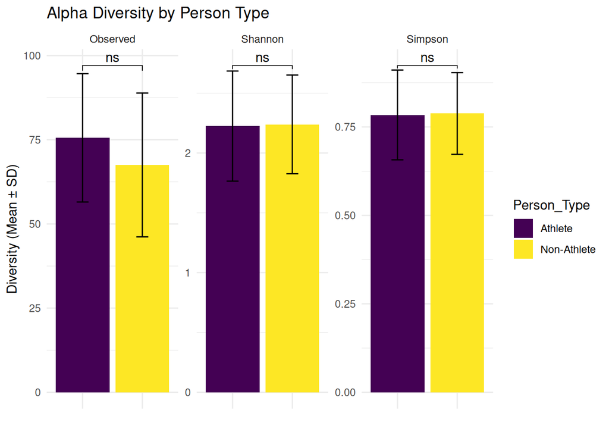

```r
supfig1 <- alpha_diversity %>%
  gather(key = "DiversityIndex", value = "Value", -Person_Type) %>%
  group_by(Person_Type, DiversityIndex) %>%
  summarize(MeanDiversity = mean(Value), SD = sd(Value)) %>%
  ggplot(aes(x = Person_Type, y = MeanDiversity, fill = Person_Type)) +
  geom_bar(stat = "identity", position = position_dodge()) +
  facet_wrap(~DiversityIndex, scales = "free") +
  geom_errorbar(aes(ymin = MeanDiversity - SD, ymax = MeanDiversity + SD), width = 0.2, position = position_dodge(0.9)) +
  theme_minimal() +
  stat_compare_means(comparisons = list(c("Non-Athlete","Athlete")),label = 'p.signif')+
  theme(axis.text.x = element_blank(), axis.ticks.x = element_blank())+
  labs(title = "Alpha Diversity by Person Type", y = "Diversity (Mean ± SD)", x = "")
supfig1
```

```r
# Kruskal-Wallis test for Shannon diversity
kruskal.test(Shannon ~ Person_Type, data = alpha_diversity)
```

```
##
##  Kruskal-Wallis rank sum test
##
## data:  Shannon by Person_Type
## Kruskal-Wallis chi-squared = 0.022624, df = 1, p-value = 0.8804
```

```r
# Supp Fig 1 DP1=300
ggsave("SuppFigure1.png", supfig1, width = 12, height = 10, dpi = 300, bg = "white")
```

## Determining how much of region plays a role in GM compostion.

### PCoA Region Plot - Aitchison distance - Figure 2 A

#### Begin my applying the CLR tranformation function from Data prep, Normilzation section (Converts raw data counts into Relative abundance). Euclidean distance was used on transofrmed data (making it an Aitchison model) to preserve the relationshps between transformed values. To visualze the model convert the PCoA to a dataframe to construct a scatterplot with ggplot. Permenova test determines the variance explained and significance of region on GM compostion.

```r
#Libraries
library(phyloseq)  # For microbiome data handling
library(vegan)     # For calculating distance and performing PERMANOVA
```

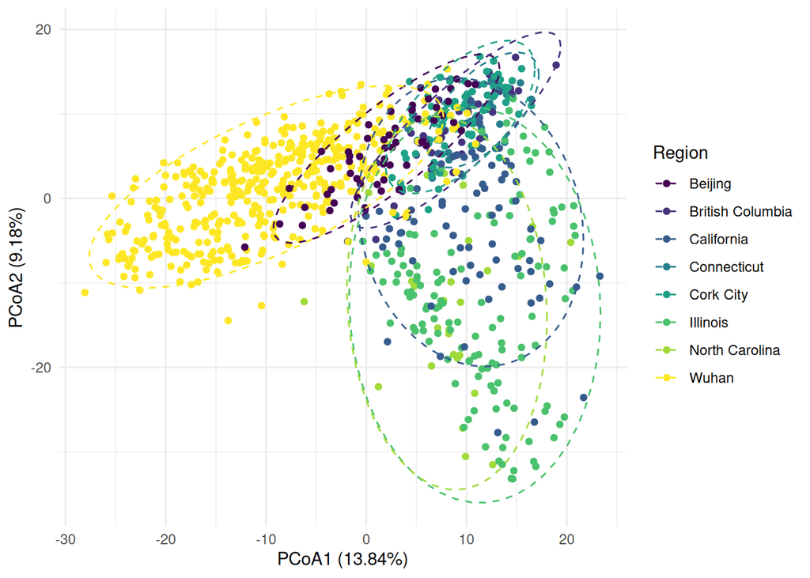

```r
library(ggplot2)   # For visualizing the PCoA
library(viridis)   # For adding color scale to plot
# Apply CLR transformation function across taxa
otu_matrix <- otu_table(ath2_rel_abundance_pseudo)
otu_matrix_clr <- apply(otu_matrix, 2, clr_transformation)

# Calculate Euclidean distance on CLR-transformed data
distance_matrix <- vegdist(t(otu_matrix_clr), method = "euclidean")

# Perform PCoA using the distance matrix
pcoa_results <- cmdscale(distance_matrix, eig = TRUE, k = 2)  # k is the number of dimensions

# Convert PCoA results to a dataframe for ggplot
pcoa_df <- as.data.frame(pcoa_results$points)
pcoa_df$Region <- sample_data(ath2_rel_abundance_pseudo)$Region

# Calculate percentage of variance explained by each axis
variance_explained <- pcoa_results$eig / sum(pcoa_results$eig) * 100

# Convert PCoA results to a dataframe for ggplot
pcoa_df <- as.data.frame(pcoa_results$points)
pcoa_df$Region <- sample_data(ath2_rel_abundance_pseudo)$Region

# Modify axis labels to include variance explained
x_label <- paste0("PCoA1 (", round(variance_explained[1], 2), "%)")
y_label <- paste0("PCoA2 (", round(variance_explained[2], 2), "%)")

# Plotting PCoA with Aitchison Distance for Region
Fig2A <- ggplot(pcoa_df, aes(x = V1, y = V2, color = Region)) +
  geom_point() +
  labs(x = x_label, y = y_label) +
  theme_minimal() +
  stat_ellipse(type = "t", level = 0.95, linetype = 2) +
  scale_color_viridis_d()

Fig2A
```

```r
# Permanova to test significance based on Region
sample_metadata <- data.frame(sample_data(ath2_rel_abundance_pseudo))
permanova_results <- adonis2(distance_matrix ~ Region, data = sample_metadata, permutations = 999)
print(permanova_results)
```

```
## Permutation test for adonis under reduced model
## Permutation: free
## Number of permutations: 999
##
## adonis2(formula = distance_matrix ~ Region, data = sample_metadata, permutations = 999)
##           Df SumOfSqs      R2      F Pr(>F)
## Model      7   169524 0.19987 30.226  0.001 ***
## Residual 847   678637 0.80013
## Total    854   848162 1.00000
## ---
## Signif. codes:  0 '***' 0.001 '**' 0.01 '*' 0.05 '.' 0.1 ' ' 1
```

### PCoA Person_Type (Athlete v. Non) Plot - Aitchison distance - Fig2B

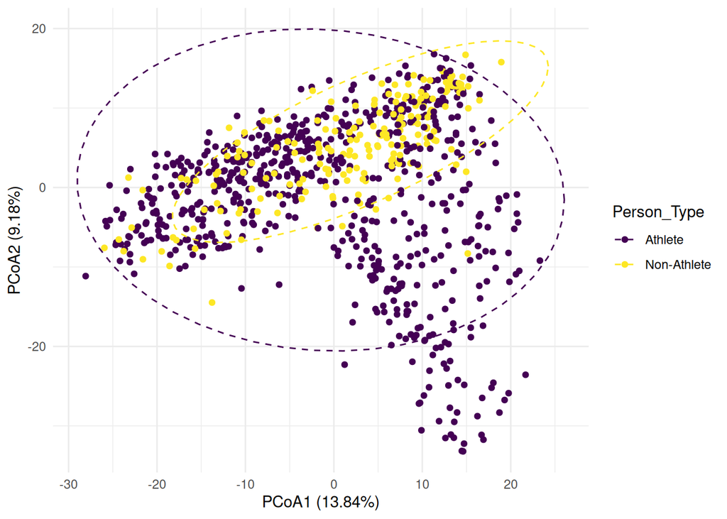

```r
#Libraries
library(phyloseq)  # For microbiome data handling
library(vegan)     # For calculating distance and performing PERMANOVA
library(ggplot2)   # For visualizing the PCoA
library(viridis)   # For adding color scale to plot

# Apply CLR transformation across taxa
otu_matrix <- otu_table(ath2_rel_abundance_pseudo)
otu_matrix_clr <- apply(otu_matrix, 2, clr_transformation)

# Calculate Euclidean distance on CLR-transformed data
distance_matrix <- vegdist(t(otu_matrix_clr), method = "euclidean")

# Perform PCoA using the distance matrix
pcoa_results <- cmdscale(distance_matrix, eig = TRUE, k = 2)  # k is the number of dimensions

# Convert PCoA results to a dataframe for ggplot
pcoa_df_Person_Type <- as.data.frame(pcoa_results$points)
pcoa_df_Person_Type$Person_Type <- sample_data(ath2_rel_abundance_pseudo)$Person_Type
# Calculate percentage of variance explained by each axis
variance_explained <- pcoa_results$eig / sum(pcoa_results$eig) * 100

# Convert PCoA results to a dataframe for ggplot
pcoa_df_Person_Type <- as.data.frame(pcoa_results$points)
pcoa_df_Person_Type$Person_Type <- sample_data(ath2_rel_abundance_pseudo)$Person_Type

# Modify axis labels to include variance explained
x_label <- paste0("PCoA1 (", round(variance_explained[1], 2), "%)")
y_label <- paste0("PCoA2 (", round(variance_explained[2], 2), "%)")

# Plotting PCoA with Aitchison Distance for Person_Type
Fig2B <- ggplot(pcoa_df_Person_Type, aes(x = V1, y = V2, color = Person_Type)) +
  geom_point() +
  labs(x = x_label, y = y_label) +
  theme_minimal() +
  stat_ellipse(type = "t", level = 0.95, linetype = 2) +
  scale_color_viridis_d()

Fig2B
```

```r
# Permanova to test significance based on Person_Type
sample_metadata <- data.frame(sample_data(ath2_rel_abundance_pseudo))
permanova_results_Person_Type <- adonis2(distance_matrix ~ Person_Type, data = sample_metadata, permutations = 999)
print(permanova_results_Person_Type)
```

```
## Permutation test for adonis under reduced model
## Permutation: free
## Number of permutations: 999
##
## adonis2(formula = distance_matrix ~ Person_Type, data = sample_metadata, permutations = 999)
##           Df SumOfSqs      R2      F Pr(>F)
## Model      1    13805 0.01628 14.113  0.001 ***
## Residual 853   834357 0.98372
## Total    854   848162 1.00000
## ---
## Signif. codes:  0 '***' 0.001 '**' 0.01 '*' 0.05 '.' 0.1 ' ' 1
```

### Mixed effects model - Fig2C

##### We set up an analysis create a genera-level data frame from a phyloseq object (ath2), using various transformations and aggregations to calculate abundances by genus and sample, and mark unspecified genera as “Unassigned.” The data is reshaped and manipulated into a format suitable for modeling, with SampleID set as row names for ease of processing. Next, create covariates (Status and Region) and incorporate them into a combined dataset with abundance data, preparing for mixed-effects modeling. Using the mms function, fitting a mixed-effects model that examines genus abundance based on sample status while accounting for region variability as a random effect. The model outputs are processed to extract and display genus-level effect estimates, which are summarized in a data frame (results_df). Finally, visualize the estimated effects across genera using ggplot2, creating a bar chart that highlights the estimated effects of each genus.

```r
# Removes warnning messages from markdown
options(warn = -1)

#Libraries
library(NBZIMM)    # For analyzing zero-inflated negative binomial mixed models
library(ZIBR)      # For fitting zero-inlfated models to microbiome data
```

```r
library(ggplot2)   # For visualizing the Model
library(ggpubr)    # For combing and annotating figures

# Make a data from from the phyloseq
ath.genera <- ath2 %>%
  tax_glom(taxrank = "Genus") %>%                     # agglomerate at phylum level
  #transform_sample_counts(function(x) {x/sum(x)} ) %>% # Transform to rel. abundance
  psmelt() %>%                                         # Melt to long format
  #filter(Abundance > 0.01) %>%                         # Filter out low abundance taxa
  arrange(Order)                                      # Sort data frame alphabetically by phylum

# Aggregrate Table
ath.agg <- aggregate(Abundance ~ Genus + SampleID, ath.genera, FUN = sum)

# Make Blank Cells Unspecified
ath.agg$Genus[ath.agg$Genus == ""] <- "Unassigned"

# Manipulate Data Table to Short Version
ath.agg.otus <- as.data.frame(reshape::cast(ath.agg, SampleID ~ Genus, sum))
# Make SampleID Rownames and Remove Column
rownames(ath.agg.otus) <- ath.agg.otus$SampleID
ath.agg.otus$SampleID <- NULL

# Check Dimensions
dim(ath.agg.otus)
```

```
## [1] 855 419
```

```r
### Create Variables for Model ###
# Sample Data
Status <- ath.genera$Person_Type
Region <- ath.genera$Region

# Combine the abundance data with the covariates
ath.agg.combined <- cbind(ath.agg.otus, Status = Status, Region = Region)

# Generate Mixed Effect Model
ath.lme.model <- mms(
  y = ath.agg.otus,
  fixed = ~ Status,
  random = ~ 1 | Region,
  data = ath.agg.combined,  # Specify the data object containing covariates
  min.p = 0.2,
  method = "nb"
)
```

```
## Analyzing 76 responses:
```

[output not shown]

```r
# Extract model results and create a data frame of the significant taxa using NBZIMM
ath.diff.results <- ath.lme.model$fit  # Extract the list of fits for each genus

# Initialize an empty list to store results
results_list <- list()

# Iterate through each fit and extract all available coefficients
for (genus in names(ath.diff.results)) {
  if (!is.null(ath.diff.results[[genus]])) {
    message("Genus: ", genus)
    message("Available fields: ", paste(names(ath.diff.results[[genus]]), collapse = ", "))
    # Extract coefficients if available
    if (!is.null(ath.diff.results[[genus]]$coefficients)) {
      coefficients <- ath.diff.results[[genus]]$coefficients
      for (coef_name in names(coefficients)) {
        estimate <- coefficients[[coef_name]]
        if (is.numeric(estimate)) {
          results_list <- append(results_list, list(data.frame(Genus = genus, Coefficient = coef_name, Estimate = as.numeric(estimate))))
        }
      }
    }
  }
}
```

[output not shown]

[output not shown]

[output not shown]

[output not shown]

[output not shown]

[output not shown]

[output not shown]

[output not shown]

[output not shown]

[output not shown]

[output not shown]

[output not shown]

[output not shown]

[output not shown]

[output not shown]

[output not shown]

[output not shown]

[output not shown]

[output not shown]

[output not shown]

[output not shown]

[output not shown]

[output not shown]

[output not shown]

[output not shown]

[output not shown]

[output not shown]

[output not shown]

[output not shown]

[output not shown]

[output not shown]

[output not shown]

[output not shown]

[output not shown]

[output not shown]

[output not shown]

[output not shown]

[output not shown]

[output not shown]

[output not shown]

[output not shown]

[output not shown]

[output not shown]

[output not shown]

[output not shown]

[output not shown]

[output not shown]

[output not shown]

[output not shown]

[output not shown]

[output not shown]

[output not shown]

[output not shown]

[output not shown]

[output not shown]

[output not shown]

[output not shown]

[output not shown]

[output not shown]

[output not shown]

[output not shown]

[output not shown]

[output not shown]

[output not shown]

[output not shown]

[output not shown]

[output not shown]

[output not shown]

[output not shown]

[output not shown]

[output not shown]

[output not shown]

[output not shown]

```
## Available fields: modelStruct, dims, contrasts, coefficients, varFix, sigma, apVar, logLik, numIter, groups, call, terms, method, fitted, residuals, fixDF, na.action, data, iter, theta
```

```
## Genus: Gemella
```

```
## Available fields: modelStruct, dims, contrasts, coefficients, varFix, sigma, apVar, logLik, numIter, groups, call, terms, method, fitted, residuals, fixDF, na.action, data, iter, theta
```

```
## Genus: Haemophilus
```

```
## Available fields: modelStruct, dims, contrasts, coefficients, varFix, sigma, apVar, logLik, numIter, groups, call, terms, method, fitted, residuals, fixDF, na.action, data, iter, theta
```

```
## Genus: Holdemania
```

```
## Available fields: modelStruct, dims, contrasts, coefficients, varFix, sigma, apVar, logLik, numIter, groups, call, terms, method, fitted, residuals, fixDF, na.action, data, iter, theta
```

```
## Genus: Klebsiella
```

```
## Available fields: modelStruct, dims, contrasts, coefficients, varFix, sigma, apVar, logLik, numIter, groups, call, terms, method, fitted, residuals, fixDF, na.action, data, iter, theta
```

```
## Genus: Lachnobacterium
```

```
## Available fields: modelStruct, dims, contrasts, coefficients, varFix, sigma, apVar, logLik, numIter, groups, call, terms, method, fitted, residuals, fixDF, na.action, data, iter, theta
```

```
## Genus: Lachnospira
```

```
## Available fields: modelStruct, dims, contrasts, coefficients, varFix, sigma, apVar, logLik, numIter, groups, call, terms, method, fitted, residuals, fixDF, na.action, data, iter, theta
```

```
## Genus: Lactobacillus
```

```
## Available fields: modelStruct, dims, contrasts, coefficients, varFix, sigma, apVar, logLik, numIter, groups, call, terms, method, fitted, residuals, fixDF, na.action, data, iter, theta
```

```
## Genus: Lactococcus
```

```
## Available fields: modelStruct, dims, contrasts, coefficients, varFix, sigma, apVar, logLik, numIter, groups, call, terms, method, fitted, residuals, fixDF, na.action, data, iter, theta
```

```
## Genus: Megamonas
```

```
## Available fields: modelStruct, dims, contrasts, coefficients, varFix, sigma, apVar, logLik, numIter, groups, call, terms, method, fitted, residuals, fixDF, na.action, data, iter, theta
```

```
## Genus: Megasphaera
```

```
## Available fields: modelStruct, dims, contrasts, coefficients, varFix, sigma, apVar, logLik, numIter, groups, call, terms, method, fitted, residuals, fixDF, na.action, data, iter, theta
```

```
## Genus: Mogibacterium
```

```
## Available fields: modelStruct, dims, contrasts, coefficients, varFix, sigma, apVar, logLik, numIter, groups, call, terms, method, fitted, residuals, fixDF, na.action, data, iter, theta
```

```
## Genus: Odoribacter
```

```
## Available fields: modelStruct, dims, contrasts, coefficients, varFix, sigma, apVar, logLik, numIter, groups, call, terms, method, fitted, residuals, fixDF, na.action, data, iter, theta
```

```
## Genus: Oscillospira
```

```
## Available fields: modelStruct, dims, contrasts, coefficients, varFix, sigma, apVar, logLik, numIter, groups, call, terms, method, fitted, residuals, fixDF, na.action, data, iter, theta
```

```
## Genus: Oxalobacter
```

```
## Available fields: modelStruct, dims, contrasts, coefficients, varFix, sigma, apVar, logLik, numIter, groups, call, terms, method, fitted, residuals, fixDF, na.action, data, iter, theta
```

```
## Genus: Parabacteroides
```

```
## Available fields: modelStruct, dims, contrasts, coefficients, varFix, sigma, apVar, logLik, numIter, groups, call, terms, method, fitted, residuals, fixDF, na.action, data, iter, theta
```

```
## Genus: Paraprevotella
```

```
## Available fields: modelStruct, dims, contrasts, coefficients, varFix, sigma, apVar, logLik, numIter, groups, call, terms, method, fitted, residuals, fixDF, na.action, data, iter, theta
```

```
## Genus: Parvimonas
```

```
## Available fields: modelStruct, dims, contrasts, coefficients, varFix, sigma, apVar, logLik, numIter, groups, call, terms, method, fitted, residuals, fixDF, na.action, data, iter, theta
```

```
## Genus: Peptoniphilus
```

```
## Available fields: modelStruct, dims, contrasts, coefficients, varFix, sigma, apVar, logLik, numIter, groups, call, terms, method, fitted, residuals, fixDF, na.action, data, iter, theta
```

```
## Genus: Peptostreptococcus
```

```
## Available fields: modelStruct, dims, contrasts, coefficients, varFix, sigma, apVar, logLik, numIter, groups, call, terms, method, fitted, residuals, fixDF, na.action, data, iter, theta
```

```
## Genus: Phascolarctobacterium
```

```
## Available fields: modelStruct, dims, contrasts, coefficients, varFix, sigma, apVar, logLik, numIter, groups, call, terms, method, fitted, residuals, fixDF, na.action, data, iter, theta
```

```
## Genus: Porphyromonas
```

```
## Available fields: modelStruct, dims, contrasts, coefficients, varFix, sigma, apVar, logLik, numIter, groups, call, terms, method, fitted, residuals, fixDF, na.action, data, iter, theta
```

```
## Genus: Prevotella
```

```
## Available fields: modelStruct, dims, contrasts, coefficients, varFix, sigma, apVar, logLik, numIter, groups, call, terms, method, fitted, residuals, fixDF, na.action, data, iter, theta
```

```
## Genus: Pseudomonas
```

```
## Available fields: modelStruct, dims, contrasts, coefficients, varFix, sigma, apVar, logLik, numIter, groups, call, terms, method, fitted, residuals, fixDF, na.action, data, iter, theta
```

```
## Genus: Roseburia
```

```
## Available fields: modelStruct, dims, contrasts, coefficients, varFix, sigma, apVar, logLik, numIter, groups, call, terms, method, fitted, residuals, fixDF, na.action, data, iter, theta
```

```
## Genus: Rothia
```

```
## Available fields: modelStruct, dims, contrasts, coefficients, varFix, sigma, apVar, logLik, numIter, groups, call, terms, method, fitted, residuals, fixDF, na.action, data, iter, theta
```

```
## Genus: Ruminococcus
```

```
## Available fields: modelStruct, dims, contrasts, coefficients, varFix, sigma, apVar, logLik, numIter, groups, call, terms, method, fitted, residuals, fixDF, na.action, data, iter, theta
```

```
## Genus: Serratia
```

```
## Available fields: modelStruct, dims, contrasts, coefficients, varFix, sigma, apVar, logLik, numIter, groups, call, terms, method, fitted, residuals, fixDF, na.action, data, iter, theta
```

```
## Genus: Shigella
```

```
## Available fields: modelStruct, dims, contrasts, coefficients, varFix, sigma, apVar, logLik, numIter, groups, call, terms, method, fitted, residuals, fixDF, na.action, data, iter, theta
```

```
## Genus: SMB53
```

```
## Available fields: modelStruct, dims, contrasts, coefficients, varFix, sigma, apVar, logLik, numIter, groups, call, terms, method, fitted, residuals, fixDF, na.action, data, iter, theta
```

```
## Genus: Staphylococcus
```

```
## Available fields: modelStruct, dims, contrasts, coefficients, varFix, sigma, apVar, logLik, numIter, groups, call, terms, method, fitted, residuals, fixDF, na.action, data, iter, theta
```

```
## Genus: Streptococcus
```

```
## Available fields: modelStruct, dims, contrasts, coefficients, varFix, sigma, apVar, logLik, numIter, groups, call, terms, method, fitted, residuals, fixDF, na.action, data, iter, theta
```

```
## Genus: Sutterella
```

```
## Available fields: modelStruct, dims, contrasts, coefficients, varFix, sigma, apVar, logLik, numIter, groups, call, terms, method, fitted, residuals, fixDF, na.action, data, iter, theta
```

```
## Genus: Trabulsiella
```

```
## Available fields: modelStruct, dims, contrasts, coefficients, varFix, sigma, apVar, logLik, numIter, groups, call, terms, method, fitted, residuals, fixDF, na.action, data, iter, theta
```

```
## Genus: Turicibacter
```

```
## Available fields: modelStruct, dims, contrasts, coefficients, varFix, sigma, apVar, logLik, numIter, groups, call, terms, method, fitted, residuals, fixDF, na.action, data, iter, theta
```

```
## Genus: Unclassified
```

```
## Available fields: modelStruct, dims, contrasts, coefficients, varFix, sigma, apVar, logLik, numIter, groups, call, terms, method, fitted, residuals, fixDF, na.action, data, iter, theta
```

```
## Genus: Veillonella
```

```
## Available fields: modelStruct, dims, contrasts, coefficients, varFix, sigma, apVar, logLik, numIter, groups, call, terms, method, fitted, residuals, fixDF, na.action, data, iter, theta
```

```
## Genus: WAL_1855D
```

```
## Available fields: modelStruct, dims, contrasts, coefficients, varFix, sigma, apVar, logLik, numIter, groups, call, terms, method, fitted, residuals, fixDF, na.action, data, iter, theta
```

```r
# Combine all results into a data frame
results_df <- do.call(rbind, results_list)

# Print summary of results_df for debugging
print(head(results_df))
```

```
##            Genus Coefficient     Estimate
## 1           1-68       fixed  4.037988702
## 2           1-68       fixed  0.018032432
## 3  Acinetobacter       fixed  0.762063394
## 4  Acinetobacter       fixed  0.001141613
## 5 Actinobacillus       fixed  1.807558131
## 6 Actinobacillus       fixed -0.015278687
```

```r
print(dim(results_df))
```

```
## [1] 148   3
```

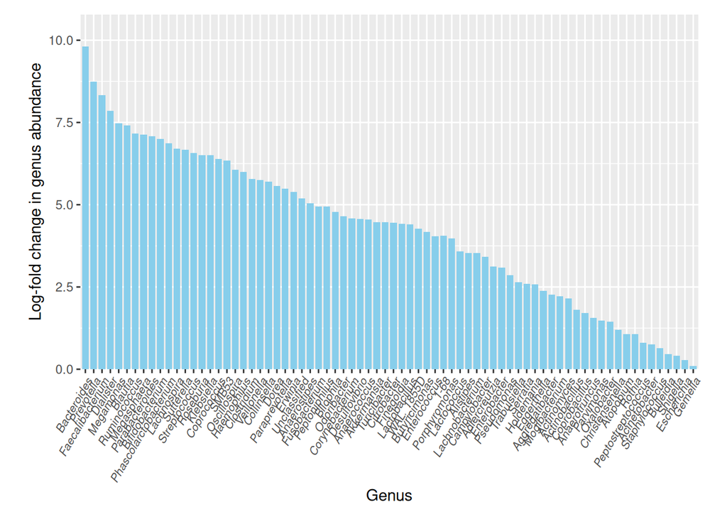

```r
# Convert Genus to a formatted expression for italics
results_df2 <- results_df %>%
  mutate(Genus = factor(Genus, levels = unique(Genus),
                        labels = paste0("italic('", unique(Genus), "')")))

# Create a ggplot visualization with italicized x-axis labels
Fig2C <- if (nrow(results_df2) > 0) {
  ggplot(data = results_df2, aes(x = reorder(Genus, -abs(Estimate)), y = Estimate)) +
    geom_bar(stat = "identity", fill = "skyblue", width = 0.8) +
    scale_y_continuous(expand = c(0, 0), limits = c(0, max(results_df$Estimate) * 1.1)) +
    labs(x = "Genus", y = "Log-fold change in genus abundance") +
    theme(axis.text.x = element_text(angle = 60, hjust = 1, vjust = 1, size = 8),
          plot.margin = unit(c(10, 20, 10, 20), "pt")) +
    scale_x_discrete(labels = scales::parse_format())  # Ensure italics are rendered
} else {
  message("No valid data available for plotting.")
}

Fig2C
```

### Merge Fig 2A-C into png with 300 DPI

```r
# Clean up Fig2C for merge
Fig2C_clean <- Fig2C +
  theme_classic() +  # Removes gray background
  theme(panel.grid.major = element_blank(),
        panel.grid.minor = element_blank(),
        panel.background = element_blank(),
        axis.text.x = element_text(angle = 45, hjust = 1, vjust = 1, size = 8))  # Rotate x-axis text


# Arrange A and B in a single row with equal widths
Fig2_top <- ggarrange(Fig2A, Fig2B, labels = c("A", "B"),
                      ncol = 2, widths = c(1, 1))  # Ensures same size

# Place C below, spanning full width
Fig2 <- ggarrange(Fig2_top, Fig2C_clean, labels = c("", "C"),
                  ncol = 1, nrow = 2, heights = c(1, 1.3))  # Stretch C

ggsave("Figure2.png", Fig2, width = 12, height = 10, dpi = 300, bg = "white")
```

### Catagorical OOB RF for Person_Type (Athlete v. Non) from top 20 identifed in mixed effect model - Fig3A-B

#### The top 20 genera were selected based on the absolute estimated effect size from results_df and filtered from the phyloseq object (ath2). A Random Forest model was trained using the filtered dataset to classify samples as either Athlete or Non-Athlete, with OTU abundance as predictors. Feature importance scores (Mean Decrease Accuracy) were extracted and visualized to determine the key genera driving classification. A Wilcoxon rank-sum test was performed to compare microbial abundance between Athlete and Non-Athlete groups for each genus, identifying those with statistically significant differences (p < 0.05). Finally, a box plot was generated to visualize the abundance of the significant genera between the groups, with log-transformed y-axis and annotated p-values indicating significance.

```r
# Libraries
library(phyloseq)      # For microbiome data handling
library(randomForest)  # For random forest modeling
library(ggplot2)       # For plotting
library(dplyr)         # For data manipulation
library(ggpubr)        # For adding statistical annotations to ggplots

# Select top 20 genera based on the absolute estimated effect size
top_20_genera <- results_df %>%
  arrange(desc(abs(Estimate))) %>%
  head(20) %>%
  pull(Genus)

# Filter phyloseq object to include only top 20 genera
# Subset the OTUs in the phyloseq object to match the top 20 genera
ath2_top20 <- subset_taxa(ath2, Genus %in% top_20_genera)

# Make Training Dataset for Random Forest using filtered phyloseq
predict_top20 <- t(otu_table(ath2_top20))  # Create OTU abundance matrix for RF

# Create response variable (Athlete vs. Non-Athlete)
res <- sample_data(ath2_top20)$Person_Type

# Combine them into one data frame for Random Forest
machine.data_top20 <- data.frame(res, predict_top20)

# Check dimensions before proceeding
dim(machine.data_top20)
```

```
## [1] 855  21
```

```r
# Run Random Forest Model with the Top 20 Genera
set.seed(8)
class.ath4_top20 <- randomForest(res ~ ., data = machine.data_top20, ntree = 1000, importance = TRUE)
print(class.ath4_top20)
```

```
##
## Call:
##  randomForest(formula = res ~ ., data = machine.data_top20, ntree = 1000,      importance = TRUE)
##                Type of random forest: classification
##                      Number of trees: 1000
## No. of variables tried at each split: 4
##
##         OOB estimate of  error rate: 14.27%
## Confusion matrix:
##             Athlete Non-Athlete class.error
## Athlete         644          12  0.01829268
## Non-Athlete     110          89  0.55276382
```

```r
# Extract importance scores for visualization or analysis
impcl_top20 <- randomForest::importance(class.ath4_top20)
impcl_df_top20 <- data.frame(OTUID = rownames(impcl_top20), impcl_top20)

# Print top genera based on random forest analysis
print(impcl_df_top20)
```

```
##           OTUID  Athlete Non.Athlete MeanDecreaseAccuracy MeanDecreaseGini
## X851865 X851865 13.18625   10.412861             18.16316        13.879348
## X968675 X968675 11.95972    5.326058             13.28032        10.738617
## X555945 X555945 20.27822   12.650971             25.73300        14.555462
## X264967 X264967 18.33155   21.769783             24.34515        11.165219
## X335550 X335550 16.28690   16.138810             22.68179        15.141478
## X589277 X589277 18.40564   11.570430             22.58260        15.250570
## X369486 X369486 27.82058   29.140719             36.47066        23.679449
## X180082 X180082 25.15959    1.753036             23.47586        14.262874
## X359809 X359809 15.55128   17.993866             22.95698        17.128049
## X545061 X545061 10.93542    5.791339             12.71573        10.995726
## X514272 X514272 15.88363   18.380381             23.50648        17.389322
## X701221 X701221 19.80036    1.095442             18.72482        13.222868
## X532203 X532203 12.08871   35.966957             32.66650        24.865608
## X523140 X523140 10.40178    4.653921             11.47010        11.095657
## X556835 X556835 19.94917   16.349733             25.04281        15.241024
## X72820   X72820 18.96503    2.649167             18.43718        12.867955
## X325808 X325808 11.87630    9.603998             15.25678         6.313158
## X246930 X246930 24.81783   24.587392             32.09684        24.209245
## X579608 X579608 18.95061   23.619834             28.92100        22.494739
## X813217 X813217 14.41343   22.251055             24.40206        10.314210
```

```r
# Get the top 20 genera based on MeanDecreaseAccuracy
impcl_top20 <- impcl_df_top20 %>%
  arrange(desc(MeanDecreaseAccuracy)) %>%
  head(20)

# Prepare the OTU dataframe with taxonomic information
otu_df <- as.data.frame(tax_table(ath2))
otu_df$OTUID <- rownames(otu_df)

# Remove any "X" prefix from OTUIDs in impcl_top20 and otu_df to ensure consistency
impcl_top20$OTUID <- gsub("^X", "", impcl_top20$OTUID)
otu_df$OTUID <- gsub("^X", "", otu_df$OTUID)

# Convert OTUID columns to character type to ensure compatibility
impcl_top20$OTUID <- as.character(impcl_top20$OTUID)
otu_df$OTUID <- as.character(otu_df$OTUID)

# Merge the importance scores with taxonomic information again
imp_merged <- merge(impcl_top20, otu_df, by = "OTUID")
print(imp_merged)   # Check if imp_merged now contains data
```

```
##     OTUID  Athlete Non.Athlete MeanDecreaseAccuracy MeanDecreaseGini   Domain
## 1  180082 25.15959    1.753036             23.47586        14.262874 Bacteria
## 2  246930 24.81783   24.587392             32.09684        24.209245 Bacteria
## 3  264967 18.33155   21.769783             24.34515        11.165219 Bacteria
## 4  325808 11.87630    9.603998             15.25678         6.313158 Bacteria
## 5  335550 16.28690   16.138810             22.68179        15.141478 Bacteria
## 6  359809 15.55128   17.993866             22.95698        17.128049 Bacteria
## 7  369486 27.82058   29.140719             36.47066        23.679449 Bacteria
## 8  514272 15.88363   18.380381             23.50648        17.389322 Bacteria
## 9  523140 10.40178    4.653921             11.47010        11.095657 Bacteria
## 10 532203 12.08871   35.966957             32.66650        24.865608 Bacteria
## 11 545061 10.93542    5.791339             12.71573        10.995726 Bacteria
## 12 555945 20.27822   12.650971             25.73300        14.555462 Bacteria
## 13 556835 19.94917   16.349733             25.04281        15.241024 Bacteria
## 14 579608 18.95061   23.619834             28.92100        22.494739 Bacteria
```

[output cut: 48 more lines]

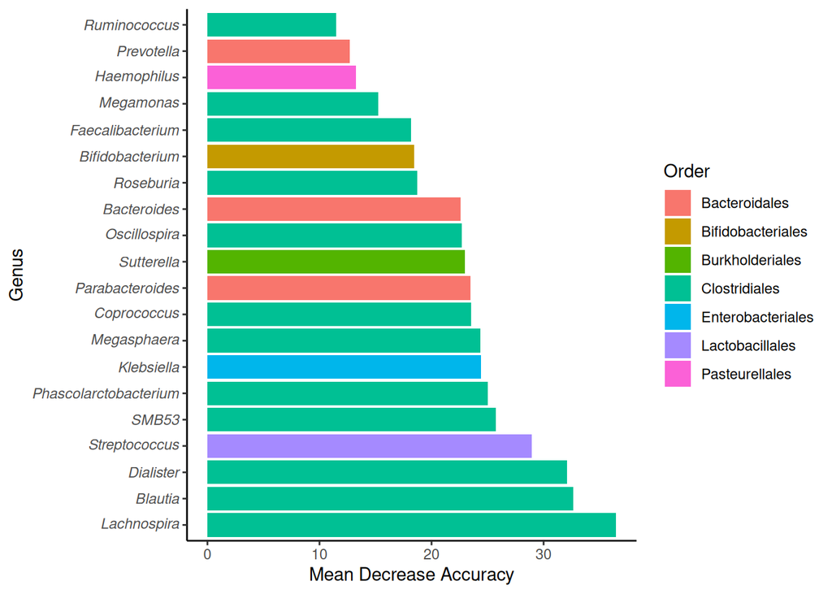

```r
# Convert Genus to an italicized expression for plotting
imp_merged2 <- imp_merged %>%
  mutate(Genus = factor(Genus, levels = unique(Genus),
                        labels = paste0("italic('", unique(Genus), "')")))

# Create ggplot visualization with italicized genus names on the x-axis
Fig3A <- ggplot(imp_merged2, aes(x = reorder(Genus, MeanDecreaseAccuracy, decreasing = TRUE),
                                y = MeanDecreaseAccuracy, fill = Order)) +
  geom_bar(stat = "identity") +
  coord_flip() +
  theme_classic() +
  labs(x = "Genus",
       y = "Mean Decrease Accuracy",
       fill = "Order") +
  scale_x_discrete(labels = scales::parse_format())  # Ensure italics are rendered correctly

Fig3A
```

```r
# Get the top genera from `imp_merged`
top_genera <- unique(imp_merged$Genus)  # Get the top 20 genera

# Create a taxa data frame from `ath2_top20`
ath_genera_top20 <- ath2_top20 %>%
  psmelt() %>%  # Melt to long format
  arrange(Order)

# Filter `ath_genera_top20` to include only the top genera
ath.genera_filtered_Top20 <- ath_genera_top20 %>%
  filter(Genus %in% top_genera)

# Perform the Wilcoxon rank-sum test for each genus between Athlete and Non-Athlete groups
Wil_Athlete_v_Non <- ath.genera_filtered_Top20 %>%
  group_by(Genus) %>%
  summarise(
    p_value = if (length(Abundance[Person_Type == "Athlete"]) > 0 && length(Abundance[Person_Type == "Non-Athlete"]) > 0) {
      wilcox.test(Abundance[Person_Type == "Athlete"], Abundance[Person_Type == "Non-Athlete"])$p.value
    } else {
      NA
    }
  )

# Check the Wilcoxon rank-sum test results
print(Wil_Athlete_v_Non)
```

```
## # A tibble: 20 × 2
##    Genus                  p_value
##    <chr>                    <dbl>
##  1 Bacteroides           3.61e- 1
##  2 Bifidobacterium       1.51e- 1
##  3 Blautia               4.58e- 5
##  4 Coprococcus           7.51e- 7
##  5 Dialister             2.02e-11
##  6 Faecalibacterium      9.94e- 1
##  7 Haemophilus           3.22e- 1
##  8 Klebsiella            6.07e- 4
##  9 Lachnospira           1.82e- 4
## 10 Megamonas             1.07e- 3
## 11 Megasphaera           1.30e-11
## 12 Oscillospira          2.15e- 2
## 13 Parabacteroides       5.02e- 1
## 14 Phascolarctobacterium 4.39e- 2
## 15 Prevotella            5.61e- 1
## 16 Roseburia             1.92e- 1
## 17 Ruminococcus          8.43e- 1
## 18 SMB53                 4.48e- 1
## 19 Streptococcus         1.58e- 3
## 20 Sutterella            6.83e- 2
```

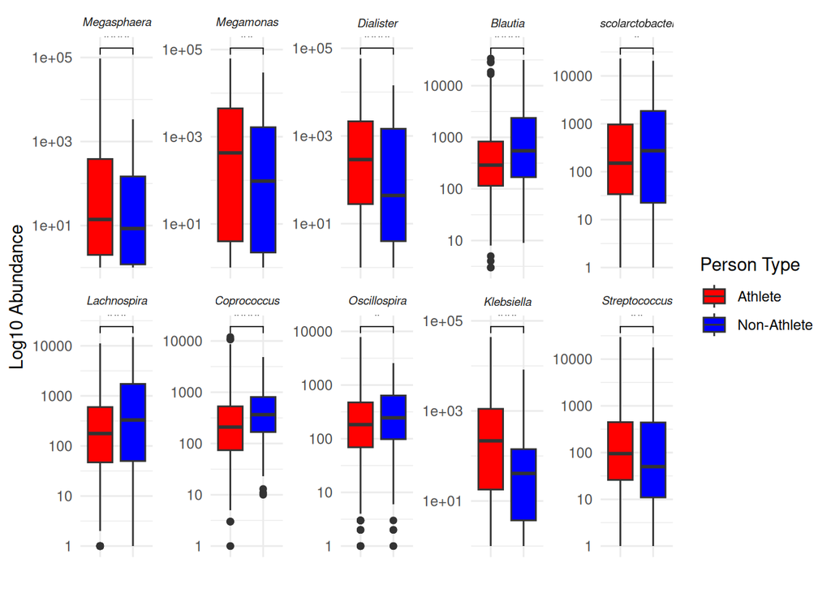

```r
# Filter to get only the significant genera based on Wilcoxon p-values
significant_genera <- Wil_Athlete_v_Non %>%
  filter(p_value < 0.05) %>%
  pull(Genus)

# Create a new filtered taxa data frame for only the significant genera
ath.genera_filtered_Significant <- ath.genera_filtered_Top20 %>%
  filter(Genus %in% significant_genera)

# Convert Genus to an italicized expression for proper ggplot parsing
ath.genera_filtered_Significant <- ath.genera_filtered_Significant %>%
  mutate(Genus = factor(Genus, levels = unique(Genus),
                        labels = paste0("italic('", unique(Genus), "')")))

# Create the box plot with Wilcoxon rank-sum test p-values for the significant genera
Fig3B <- ath.genera_filtered_Significant %>%
  filter(Person_Type %in% c("Athlete", "Non-Athlete")) %>%
  ggplot(aes(x = Person_Type, y = Abundance, fill = Person_Type)) +
  geom_boxplot() +
  scale_y_log10() +  # Log-transform the y-axis
  facet_wrap(~Genus, scales = "free_y", nrow = 2, labeller = label_parsed) +  # Italicized facet labels
  stat_compare_means(method = "wilcox.test", label = "p.signif", comparisons = list(c("Non-Athlete", "Athlete"))) +  # Annotate p-values
  labs(x = "", y = "Log10 Abundance", fill = "Person Type") +
  theme_minimal() +
  scale_fill_manual(values = c("Non-Athlete" = "blue", "Athlete" = "red")) +  # Set custom colors
  theme(
    axis.text.x = element_blank(),
    axis.ticks.x = element_blank(),
    strip.text = element_text(size = 7)  # Reduce facet title (Genus) text size
  )

Fig3B
```

```r
# Merge figure 3 into png with 300 DPI

# Extract the legend from Fig3A
legend_3A <- get_legend(Fig3A)

# Remove legend from Fig3A after extracting it
Fig3A_clean <- Fig3A + theme(legend.position = "none")
Fig3B_clean <- Fig3B + theme(legend.position = "none")

# Arrange Fig3A with its legend, placing the legend further right
Fig3A_with_legend <- ggarrange(Fig3A_clean, legend_3A,
                               ncol = 2, widths = c(3, 1))  # Increase spacing

Fig3B_clean <- Fig3B_clean + theme(
  axis.text.x = element_text(size = 6),  # Reduce font size without rotation
  strip.text = element_text(size = 7, face = "italic"),  # Increase facet label size
  plot.margin = margin(10, 10, 50, 10)   # Increase top margin for significance stars
)

Fig3B_clean <- Fig3B_clean + expand_limits(y = max(Fig3B_clean$data$Abundance) * 1.2)

# Arrange Fig3A with its legend
Fig3A_with_legend <- ggarrange(Fig3A_clean, legend_3A,
                               ncol = 2, widths = c(3, 1))  # Extra spacing for clarity
# Format Fig3
Fig3 <- ggarrange(
  Fig3A_with_legend, Fig3B_clean, # puts legend next to Fig 3A
  labels = c("A", "B"),
  ncol = 2,
  widths = c(1, 2.5),  # Make Fig3B take even more space
  heights = c(1, 1.7)  # Further increase Fig3B's height
)

# Save the final stretched version
ggsave("Figure3.png", Fig3, width = 18, height = 9, dpi = 300, bg = "white")
```

## Multilayer Perceptron (neural network) - Figure 4A-C

#### In this analysis, reproducibility was enforced by setting environment variables before loading TensorFlow/Keras—disabling GPU usage, limiting parallel threads, requesting deterministic operations, and fixing the base R seed—to ensure all subsequent random operations were reproducible. Required libraries (including keras3, tensorflow, ggplot2, caret, and ComplexHeatmap) were loaded and TensorFlow’s seed was set. The microbial abundance data from a phyloseq object was processed by applying a centered log-ratio (CLR) transformation, extracting and, if necessary, transposing the OTU table so that columns represented genera, replacing zeros with a small constant to avoid log issues, and normalizing each sample to relative abundances before merging with metadata. The dataset was then split by Person_Type (Athlete vs. Non-Athlete) and balanced via caret’s upsampling; the features were converted to numeric, scaled, and cleaned of missing or infinite values before partitioning into training and testing sets with labels encoded as Athlete = 0 and Non-Athlete = 1. A sequential neural network model with two dense layers (with dropout regularization) and a sigmoid output layer was defined, compiled with the Adam optimizer and binary crossentropy loss, and trained using early stopping and class weights to address imbalance. Model performance was evaluated on the test set by generating predictions, computing a confusion matrix (with classes renamed to Athlete and Non-Athlete) and an ROC curve with AUC calculation, and visualizing these metrics with ggplot2. Finally, for differential abundance analysis, test data was reshaped into long format and OTU identifiers were mapped to genus names (assigning “Unknown” where necessary), mean abundances were computed per genus for each predicted group, and fold-change (Pred_NonAthlete minus Pred_Athlete) was calculated; the top 50 genera by absolute fold-change were selected, an approximate reverse CLR transformation was applied to derive percent contributions, and a ComplexHeatmap was generated—with italicized genus labels and rotated x-axis labels—to visualize these contributions alongside a fold-change annotation..

```r
# Set environment variables BEFORE loading TensorFlow/Keras:
Sys.setenv(
  CUDA_VISIBLE_DEVICES = "",       # Disable GPU for stricter determinism (remove if you need GPU)
  OMP_NUM_THREADS = "1",           # Limit OpenMP threads
  TF_NUM_INTEROP_THREADS = "1",    # Limit inter-operation threads for TF
  TF_NUM_INTRAOP_THREADS = "1",    # Limit intra-operation threads for TF
  TF_DETERMINISTIC_OPS = "1",      # Request deterministic operations where possible
  PYTHONHASHSEED = "0"             # Ensure consistent hashing if Python is used
)

# Set the base R seed for reproducibility
set.seed(123)

# Load necessary libraries
library(keras3)
library(tensorflow)
```

```r
library(ggplot2)
library(reshape2)
library(caret)
library(pROC)
library(ComplexHeatmap)
# Set TensorFlow's random seed
tensorflow::set_random_seed(1234)

# CLR Transformation data of samples and taxa (855)
ath2_significant <- ath2_rel_abundance_pseudo
ath2_top20 <- transform_sample_counts(ath2_significant, clr_transformation)

# Extract OTU table and preprocess data
otu_counts <- as.data.frame(otu_table(ath2_top20))

# Transpose if taxa are rows, ensuring genera are columns
if (taxa_are_rows(ath2_top20)) {
  otu_counts <- t(otu_counts)
}

# Replace zeros with a small value to avoid issues with log transformations
otu_counts[otu_counts == 0] <- 1e-6

# Normalize to relative abundances (each sample sums to 1)
otu_rel_abund <- otu_counts / rowSums(otu_counts)

# Integrate with Metadata and Align
metadata <- data.frame(sample_data(ath2_top20))

if (!all(rownames(otu_rel_abund) == rownames(metadata))) {
  metadata <- metadata[rownames(otu_rel_abund), ]
}

# Combine OTU relative abundance and metadata
data_combined <- cbind(metadata, otu_rel_abund)

# Split by Person_Type
athlete_data <- data_combined[data_combined$Person_Type == "Athlete", ]
non_athlete_data <- data_combined[data_combined$Person_Type == "Non-Athlete", ]

# Balance the dataset using caret upsampling
set.seed(123)
upsampled_data <- upSample(x = data_combined[, !(colnames(data_combined) %in% "Person_Type")],
                           y = data_combined$Person_Type)

# Separate features and labels
otu_balanced <- as.matrix(upsampled_data[, !(colnames(upsampled_data) %in% "Class")])
labels_balanced <- upsampled_data$Class

# Convert data to numeric to avoid issues with TensorFlow
otu_balanced <- apply(otu_balanced, 2, function(x) {
  x_numeric <- suppressWarnings(as.numeric(as.character(x)))
  x_numeric[is.na(x_numeric)] <- 0  # Replace any NA values with 0
  x_numeric <- pmin(pmax(x_numeric, -1e6), 1e6)  # Clip values to a reasonable range to avoid instability
  return(x_numeric)
})

# Handle missing values in the input data
otu_balanced[is.na(otu_balanced)] <- 0  # Replace NA values with 0

# Scale the data to normalize it (e.g., standardizing it to mean 0, std 1)
otu_balanced <- scale(otu_balanced)

# Replace NaN and Inf values with zeros or a small constant
otu_balanced[is.na(otu_balanced)] <- 0
otu_balanced[is.infinite(otu_balanced)] <- 0

# Split the balanced data into training and testing sets
set.seed(123)

train_index <- createDataPartition(labels_balanced, p = 0.8, list = FALSE)
train_data <- otu_balanced[train_index, ]
test_data <- otu_balanced[-train_index, ]
train_labels <- labels_balanced[train_index]
test_labels <- labels_balanced[-train_index]

# Encode labels as numeric
train_labels_numeric <- ifelse(train_labels == "Athlete", 0, 1)
test_labels_numeric <- ifelse(test_labels == "Athlete", 0, 1)

# Define the model
input_shape <- dim(train_data)[2]

tensorflow::set_random_seed(1234)

model <- keras_model_sequential() %>%
  layer_dense(units = 256, activation = 'relu', input_shape = input_shape) %>%
  layer_dropout(rate = 0.3) %>%
  layer_dense(units = 128, activation = 'relu') %>%
  layer_dropout(rate = 0.3) %>%
  layer_dense(units = 1, activation = 'sigmoid')

# Compile the model
model %>% compile(
  optimizer = 'adam',
  loss = 'binary_crossentropy',
  metrics = c('accuracy'),
  run_eagerly = TRUE  # Enable eager execution for debugging
)

# Define class weights as a list with numeric values for each class index
class_weights <- list(
  "0" = 1,  # Assuming "Athlete" is encoded as 0
  "1" = nrow(athlete_data) / nrow(non_athlete_data)  # Assigning higher weight for underrepresented non-athletes
)

# Train the model
history <- model %>% fit(
  x = train_data,
  y = train_labels_numeric,
  epochs = 100,
  batch_size = 32,
  validation_split = 0.2,
  class_weight = class_weights,
  callbacks = list(callback_early_stopping(monitor = 'val_loss', patience = 10))
)
```

```
## 27/27 - 1s - 30ms/step - accuracy: 0.5071 - loss: 1.3869 - val_accuracy: 0.7095 - val_loss: 0.4339
## 27/27 - 1s - 27ms/step - accuracy: 0.5917 - loss: 1.1164 - val_accuracy: 0.8048 - val_loss: 0.4036
## 27/27 - 1s - 27ms/step - accuracy: 0.6667 - loss: 1.0265 - val_accuracy: 0.9286 - val_loss: 0.2084
## 27/27 - 1s - 27ms/step - accuracy: 0.7119 - loss: 0.8541 - val_accuracy: 1.0000 - val_loss: 0.0737
## 27/27 - 1s - 27ms/step - accuracy: 0.7750 - loss: 0.7396 - val_accuracy: 0.9952 - val_loss: 0.0938
## 27/27 - 1s - 27ms/step - accuracy: 0.8202 - loss: 0.5802 - val_accuracy: 0.9952 - val_loss: 0.0650
## 27/27 - 1s - 28ms/step - accuracy: 0.8298 - loss: 0.5799 - val_accuracy: 0.9810 - val_loss: 0.0843
## 27/27 - 1s - 27ms/step - accuracy: 0.8607 - loss: 0.4987 - val_accuracy: 1.0000 - val_loss: 0.0173
## 27/27 - 1s - 27ms/step - accuracy: 0.8548 - loss: 0.4869 - val_accuracy: 1.0000 - val_loss: 0.0248
## 27/27 - 1s - 27ms/step - accuracy: 0.8738 - loss: 0.4357 - val_accuracy: 0.9905 - val_loss: 0.0409
## 27/27 - 1s - 27ms/step - accuracy: 0.8905 - loss: 0.3865 - val_accuracy: 1.0000 - val_loss: 0.0108
## 27/27 - 1s - 27ms/step - accuracy: 0.8810 - loss: 0.4013 - val_accuracy: 1.0000 - val_loss: 0.0084
## 27/27 - 1s - 27ms/step - accuracy: 0.8583 - loss: 0.4484 - val_accuracy: 1.0000 - val_loss: 0.0158
## 27/27 - 1s - 27ms/step - accuracy: 0.8738 - loss: 0.4169 - val_accuracy: 1.0000 - val_loss: 0.0286
## 27/27 - 1s - 27ms/step - accuracy: 0.8929 - loss: 0.3214 - val_accuracy: 1.0000 - val_loss: 0.0161
## 27/27 - 1s - 27ms/step - accuracy: 0.9190 - loss: 0.2806 - val_accuracy: 1.0000 - val_loss: 0.0191
## 27/27 - 1s - 28ms/step - accuracy: 0.9107 - loss: 0.2966 - val_accuracy: 1.0000 - val_loss: 0.0134
## 27/27 - 1s - 28ms/step - accuracy: 0.8857 - loss: 0.3911 - val_accuracy: 0.9905 - val_loss: 0.0270
## 27/27 - 1s - 27ms/step - accuracy: 0.9012 - loss: 0.3270 - val_accuracy: 0.9905 - val_loss: 0.0187
## 27/27 - 1s - 27ms/step - accuracy: 0.9060 - loss: 0.3367 - val_accuracy: 0.9905 - val_loss: 0.0373
## 27/27 - 1s - 27ms/step - accuracy: 0.9286 - loss: 0.2409 - val_accuracy: 0.9857 - val_loss: 0.0545
## 27/27 - 1s - 27ms/step - accuracy: 0.9369 - loss: 0.1970 - val_accuracy: 0.9905 - val_loss: 0.0367
```

```r
# Predict on the test set
predicted_probabilities <- model %>% predict(test_data)
```

```
## 9/9 - 0s - 5ms/step
```

```r
predicted_labels <- ifelse(predicted_probabilities > 0.5, 1, 0)

# Calculate the confusion matrix
conf_matrix <- confusionMatrix(factor(predicted_labels), factor(test_labels_numeric))
print(conf_matrix)
```

```
## Confusion Matrix and Statistics
##
##           Reference
## Prediction   0   1
##          0 106   3
##          1  25 128
##
##                Accuracy : 0.8931
##                  95% CI : (0.8493, 0.9278)
##     No Information Rate : 0.5
##     P-Value [Acc > NIR] : < 2.2e-16
##
##                   Kappa : 0.7863
##
##  Mcnemar's Test P-Value : 7.229e-05
##
##             Sensitivity : 0.8092
##             Specificity : 0.9771
##          Pos Pred Value : 0.9725
##          Neg Pred Value : 0.8366
##              Prevalence : 0.5000
##          Detection Rate : 0.4046
##    Detection Prevalence : 0.4160
##       Balanced Accuracy : 0.8931
##
##        'Positive' Class : 0
##
```

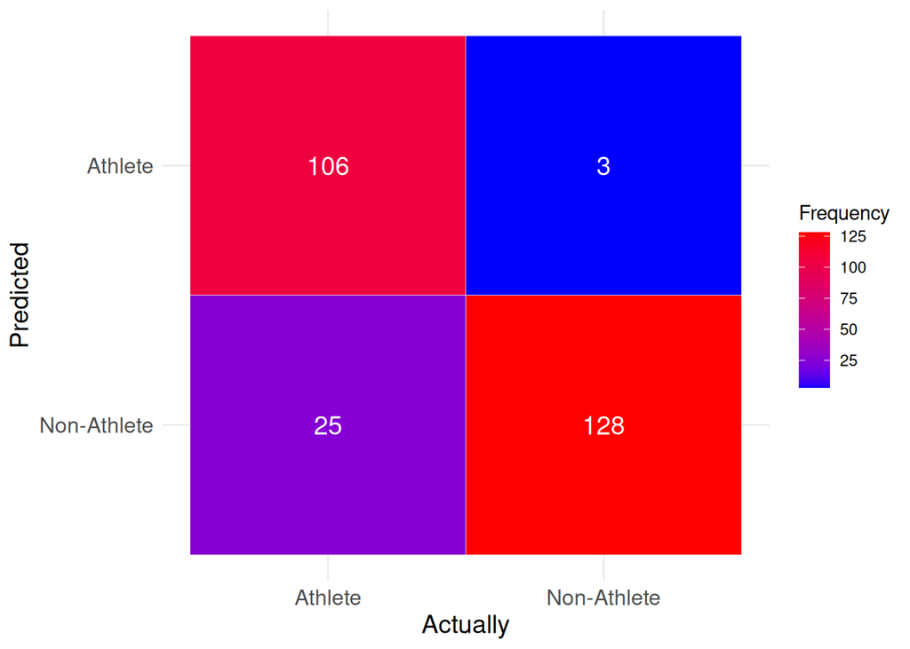

```r
# conf_matrix is the confusionMatrix object returned by caret
# Extract the table (a 2D contingency table) and convert to a data frame
cm_table <- as.data.frame(conf_matrix$table)

# Make sure we have the correct column names
colnames(cm_table) <- c("Prediction","Reference","Freq")

# Convert factor codes "0","1" --> "Athlete","Non-Athlete"
cm_table$Prediction <- factor(
  cm_table$Prediction,            # old factor with levels "0","1"
  levels = c("0", "1"),          # numeric codes in ascending order
  labels = c("Athlete","Non-Athlete")
)

cm_table$Reference <- factor(
  cm_table$Reference,
  levels = c("0", "1"),
  labels = c("Athlete","Non-Athlete")
)

#Plot with x=Reference, y=Prediction
fig4A <- ggplot(cm_table, aes(
  x = Reference,
  y = Prediction,
  fill = Freq
)) +
  geom_tile(color = "white") +
  geom_text(aes(label = Freq), color = "white", size = 5) +
  scale_fill_gradient(low = "blue", high = "red") +
  labs(x = "Actually",
       y = "Predicted",
       fill = "Frequency") +
  theme_minimal() +
  theme(
    axis.text  = element_text(size = 12),
    axis.title = element_text(size = 14)
  ) +
  ## Key line: Flip the y-axis factor order so "Athlete" is on top
  scale_y_discrete(limits = rev(levels(cm_table$Prediction)))

fig4A
```

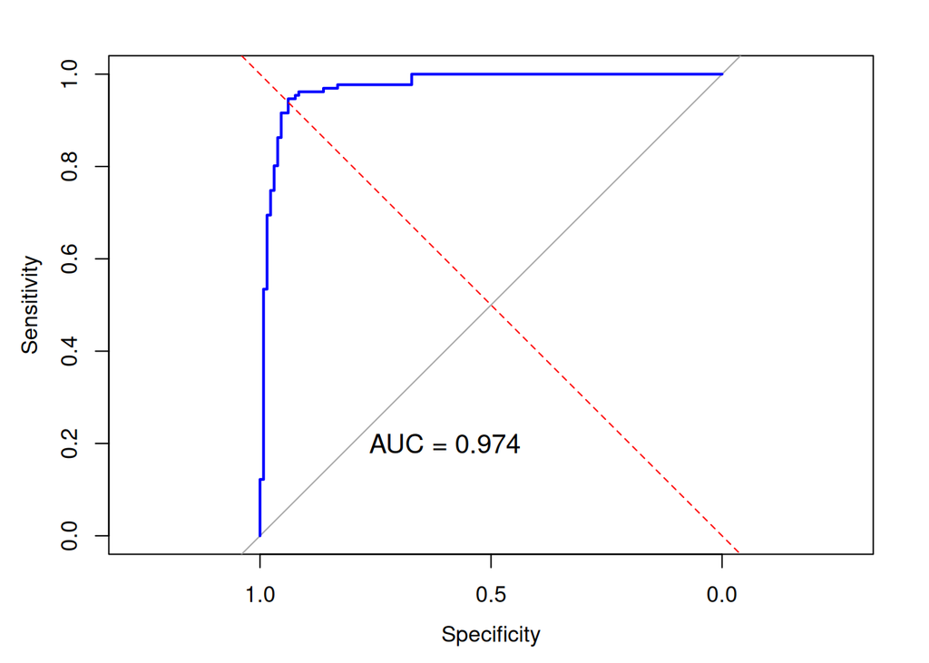

```r
# Generate the ROC curve using test labels and predicted probabilities
roc_obj <- roc(test_labels_numeric, as.numeric(predicted_probabilities))
# Plot the ROC Curve
fig4B <- plot(
  roc_obj,
  col = "blue",
  lwd = 2)
abline(a = 0, b = 1, lty = 2, col = "red")  # Diagonal reference line

# Calculate and display the AUC
auc_value <- auc(roc_obj)
text(
  x = 0.6,
  y = 0.2,
  labels = paste("AUC =", round(auc_value, 3)),
  col = "black",
  cex = 1.2
)
```

```r
# Print the AUC value to the console
print(paste(round(auc_value, 3)))
```

```
## [1] "0.974"
```

```r
fig4B
```

```
##
## Call:
## roc.default(response = test_labels_numeric, predictor = as.numeric(predicted_probabilities))
##
## Data: as.numeric(predicted_probabilities) in 131 controls (test_labels_numeric 0) < 131 cases (test_labels_numeric 1).
## Area under the curve: 0.9738
```

```r
######Heat map with Fold change##############
# Ensure rownames for test_data
if (is.null(rownames(test_data))) {
  rownames(test_data) <- paste0("Sample_", seq_len(nrow(test_data)))
}

# Convert test_data to data frame
df_test <- as.data.frame(test_data)

# Add predicted labels as a factor
df_test$Predicted <- factor(
  predicted_labels,
  levels = c(0, 1),
  labels = c("Pred_Athlete", "Pred_NonAthlete")
)

# Add SampleID column
df_test$SampleID <- rownames(df_test)

# Extract the taxa table and convert to data frame
taxa_df <- as.data.frame(tax_table(ath2_top20))  # Adjust if your taxa_table has a different name

# Create a mapping from OTU to Genus
otu_to_genus <- taxa_df$Genus
names(otu_to_genus) <- rownames(taxa_df)

# Replace NA Genus with "Unknown"
otu_to_genus[is.na(otu_to_genus)] <- "Unknown"

# Replace OTU column names in df_test with Genus names
# First, gather the data into long format
df_long <- df_test %>%
  pivot_longer(
    cols = -c("SampleID", "Predicted"),  # Exclude SampleID and Predicted
    names_to = "OTU",
    values_to = "Abundance"
  ) %>%
  mutate(Genus = otu_to_genus[OTU])

# Handle OTUs without a Genus assignment by assigning "Unknown"
df_long <- df_long %>%
  mutate(Genus = ifelse(is.na(Genus), "Unknown", Genus))

#######
# Differential Abundance Analysis Using Fold-Change
######
# Since the data is CLR-transformed, calculate the difference in mean abundances directly
df_summary <- df_long %>%
  group_by(Predicted, Genus) %>%
  summarize(
    mean_abundance = mean(Abundance, na.rm = TRUE),
    .groups = "drop"
  )

# Pivot to wide format: Rows = Genus, Columns = Predicted Labels
df_wide_agg <- df_summary %>%
  pivot_wider(
    id_cols = Genus,
    names_from = Predicted,
    values_from = mean_abundance,
    values_fill = 0
  )

# Check if 'Pred_Athlete' and 'Pred_NonAthlete' columns exist
print(colnames(df_wide_agg))
```

```
## [1] "Genus"           "Pred_Athlete"    "Pred_NonAthlete"
```

```r
# Calculate Fold-Change as the difference in mean abundances
df_wide_agg <- df_wide_agg %>%
  mutate(
    FC = `Pred_NonAthlete` - `Pred_Athlete`  # Difference in CLR-transformed means
  )

# Remove Genera that are "Unknown" if you prefer to exclude them
df_wide_agg <- df_wide_agg %>% filter(Genus != "Unknown")


# Select top 50 genera based on absolute Fold-Change
topN <- 50
top_genera <- df_wide_agg %>%
  arrange(desc(abs(FC))) %>%
  slice(1:topN) %>%
  pull(Genus)

# Subset the aggregated data to top genera and arrange alphabetically
df_wide_top <- df_wide_agg %>%
  filter(Genus %in% top_genera) %>%
  arrange(Genus)  # Sort alphabetically by Genus

# Create a matrix for heatmap
mat_agg_top <- df_wide_top %>%
  dplyr::select(`Pred_Athlete`, `Pred_NonAthlete`) %>%
  as.matrix()
rownames(mat_agg_top) <- df_wide_top$Genus

# Reverse CLR transformation (approximation by exponentiation)
mat_reversed <- exp(mat_agg_top)

# Normalize to percent contribution for each column
mat_percent <- sweep(mat_reversed, 2, colSums(mat_reversed), FUN = "/") * 100

# Verify normalization
print(colSums(mat_percent))  # Should return ~100 for each column
```

```
##    Pred_Athlete Pred_NonAthlete
##             100             100
```

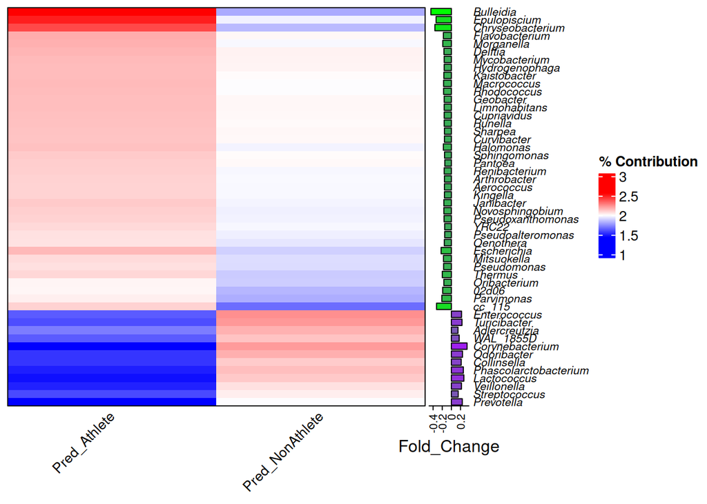

```r
# Calculate Fold Change (LFC) based on CLR-transformed data
fc_values <- mat_agg_top[, "Pred_NonAthlete"] - mat_agg_top[, "Pred_Athlete"]

# Add Fold Change to the percent contribution matrix
mat_combined <- cbind(mat_percent, Fold_Change = fc_values)

# Sort the matrix rows based on absolute Fold Change
sorted_indices <- order(abs(fc_values), decreasing = TRUE)
mat_combined_sorted <- mat_combined[sorted_indices, ]

# Define the color palette for Percent Contribution
color_palette_percent <- colorRampPalette(c("blue", "white", "red"))(100)

# Define the color palette for Fold Change
color_palette_fc <- colorRampPalette(c("green", "purple"))(100)

# Add Fold Change as an annotation
row_anno <- rowAnnotation(
  Fold_Change = anno_barplot(
    mat_combined_sorted[, "Fold_Change"],
    gp = gpar(fill = color_palette_fc[as.numeric(cut(mat_combined_sorted[, "Fold_Change"], breaks = 100))]),
    border = FALSE,
    bar_width = 0.8
  )
)

# Generate the ComplexHeatmap for Percent Contribution with Fold Change annotation
fig4C <- Heatmap(
  mat_combined_sorted[, c("Pred_Athlete", "Pred_NonAthlete")],
  name = "% Contribution",
  col = color_palette_percent,            # Your defined color palette
  row_names_gp = gpar(fontface = "italic", fontsize = 8),  # Italic row (genus) labels
  column_names_gp = gpar(fontsize = 10),     # Column name styling
  column_names_rot = 45,                     # Rotate x-axis text by 45 degrees
  heatmap_legend_param = list(title = "% Contribution"),
  right_annotation = row_anno,               # Your fold change annotation
  show_row_dend = FALSE,
  show_column_dend = FALSE,
  border = TRUE
)


fig4C
```

### Combine and convert figure 4 into 300 DPI

```r
library(ggpubr)
library(ggplotify)

# ------------------------------
# Convert and adjust Figures
# ------------------------------

# fig4A is your ggplot object for Panel A.

# Figure 4B: ROC curve (adjust margins so that x-axis is visible)
gFig4B <- as.ggplot(function() {
  par(mar = c(7, 4, 4, 2) + 0.1)  # Increase bottom margin for x-axis
  plot(roc_obj,
       col = "blue",
       lwd = 2,
       xlab = "False Positive Rate",
       ylab = "True Positive Rate")
  abline(a = 0, b = 1, lty = 2, col = "red")
  text(x = 0.6, y = 0.2,
       labels = paste("AUC =", round(auc_value, 3)),
       col = "black", cex = 1.2)
})

# Figure 4C: ComplexHeatmap (with rotated x-axis labels and italic row names)
fig4C <- Heatmap(
  mat_combined_sorted[, c("Pred_Athlete", "Pred_NonAthlete")],
  name = "% Contribution",         # Legend title; not the plot title
  col = color_palette_percent,             # Your predefined color palette
  row_names_gp = gpar(fontface = "italic", fontsize = 8),  # Italic row labels
  column_names_gp = gpar(fontsize = 10),      # Column label styling
  column_names_rot = 45,                     # Rotate x-axis labels by 45 degrees
  heatmap_legend_param = list(title = "% Contribution"),
  right_annotation = row_anno,               # Your fold-change annotation
  show_row_dend = FALSE,
  show_column_dend = FALSE,
  border = TRUE
)
gFig4C <- as.ggplot(function() {
  draw(fig4C)
})

# ------------------------------
# Arrange the Figures
# ------------------------------

# ------------------------------
# Top Row: Arrange Figures A and B Side by Side
# ------------------------------

top_row <- ggarrange(
  fig4A,   # Panel A (assumed to be a ggplot object without titles)
  gFig4B,  # Panel B (ROC curve with adjusted margins for x-axis)
  labels = c("A", "B"),
  label.x = c(0.02, 0.02),   # Adjust if needed
  label.y = c(0.98, 0.98),   # Adjust if needed
  ncol = 2, nrow = 1,
  widths = c(1, 1)
)

# ------------------------------
# Bottom Row: Panel C (the Heatmap)
# ------------------------------

# Note: We already converted our ComplexHeatmap to a ggplot object as gFig4C.
# We want to make panel C slightly smaller so it doesn't cover up the x-axis of the top row.
# We'll do that by assigning a smaller relative height when arranging the rows.

combined_figure <- ggarrange(
  top_row,   # Top row with panels A and B
  gFig4C,    # Panel C (Heatmap)
  labels = c("", "C"),    # Only panel C gets a label here (top row already has its own labels)
  label.x = c(NA, 0.02),    # Label for panel C placed at 2% from the left
  label.y = c(NA, 1.05),    # You can adjust panel C's label position if needed
  ncol = 1, nrow = 2,
  heights = c(1, 0.8)       # Top row gets height 1, bottom (C) gets 0.8 to be slightly smaller
)

# Save the merged figure
ggsave("Figure4.png", combined_figure, width = 12, height = 12, dpi = 300, bg = "white")
```

### Training and Validation extraction of the Multilayered percepton - Supplimental Figure 2 A-B

#### Extract the training and validation metrics from the multilayered percepton. Two lines plot generated using ggplot display raining and validation loss over epochs and the other plot shows corresponding training and validation. Using ggarrange puting both plots side-by-side. Figure was formatted to 300 dpi.

```r
# Libraries
library(ggpubr)


###Training and validation - Supp fig 3A-B

# Extract training and validation metrics from the history object
history_df <- data.frame(
  epoch = 1:length(history$metrics$loss),
  loss = unlist(history$metrics$loss),
  val_loss = unlist(history$metrics$val_loss),
  accuracy = unlist(history$metrics$accuracy),
  val_accuracy = unlist(history$metrics$val_accuracy)
)

# Plot Training and Validation Loss
Supp_fig2A <- ggplot(history_df, aes(x = epoch)) +
  geom_line(aes(y = loss, color = "Training Loss")) +
  geom_line(aes(y = val_loss, color = "Validation Loss")) +
  labs(
    title = "Training and Validation Loss Over Epochs",
    x = "Epoch",
    y = "Loss",
    color = "Metric"
  ) +
  theme_minimal()

# Plot Training and Validation Accuracy
Supp_fig2B <- ggplot(history_df, aes(x = epoch)) +
  geom_line(aes(y = accuracy, color = "Training Accuracy")) +
  geom_line(aes(y = val_accuracy, color = "Validation Accuracy")) +
  labs(
    title = "Training and Validation Accuracy Over Epochs",
    x = "Epoch",
    y = "Accuracy",
    color = "Metric"
  ) +
  theme_minimal()

# Combine the two plots
Supp_fig2 <- ggarrange(
  Supp_fig2A,  # Training & Validation Loss plot
  Supp_fig2B,  # Training & Validation Accuracy plot
  labels = c("A", "B"),
  ncol = 2,    # Use ncol = 1, nrow = 2 for vertical arrangement
  nrow = 1
)

# Save figure as 300 DPI
ggsave("SuppFigure2.png", Supp_fig2, width = 12, height = 6, dpi = 300, bg = "white")
```